# **ENERGY EQUITY INTELLIGENCE FRAMEWORK**

## **Integrated Analysis of Renewable Energy, Oil Markets & Macroeconomic Signals (2012–2025)**

**Prepared By:** Deng Aguer Bul  
**Data Science Student | University of Tampa**

**Project Category:** Financial Data Science • Energy Market Intelligence • Investment Analytics

**Study Period:** April 2012 – December 2025

**Data Sources**

- Yahoo Finance
- Federal Reserve Economic Data (FRED)

**Technology Stack**

- Python
- Pandas
- NumPy
- Matplotlib
- Seaborn
- Yahoo Finance API
- Pandas DataReader
- Jupyter Notebook

**Core Focus Areas**

- Renewable Energy Equity Analysis
- Oil & Gas Equity Analysis
- Macroeconomic Analysis
- Risk and Volatility Assessment
- Market Signal Development
- Investment Decision Support Systems

## **Executive Summary**

The energy sector is undergoing one of the most significant transformations in modern financial markets. While traditional oil and gas companies continue to play a critical role in global energy supply, renewable energy firms are becoming increasingly important as governments, businesses, and investors accelerate the transition toward cleaner energy sources. As a result, investors face a complex challenge: understanding how different segments of the energy market respond to changing economic conditions, commodity prices, and financial market trends.

This project develops the Energy Equity Intelligence Framework, a data-driven market intelligence system designed to analyze and compare the performance of renewable energy and oil & gas equities between 2012 and 2025. The framework integrates financial market data, commodity market indicators, and macroeconomic variables to explore whether certain economic and market conditions can help identify periods when energy stocks may become more attractive for investment research and portfolio consideration.

The analysis focuses on six representative energy companies. The renewable energy group includes NextEra Energy, First Solar, and Enphase Energy, while the traditional energy group includes ExxonMobil, Chevron, and ConocoPhillips. To provide broader market context, the study also incorporates Crude Oil Futures, the S&P 500 Index, and key macroeconomic indicators including the Federal Funds Rate, Consumer Price Index (CPI), Monthly 10-Year Treasury Yield, and Gross Domestic Product (GDP).

Using a structured financial analytics workflow, the project evaluates stock performance, monthly returns, volatility, drawdowns, macroeconomic sensitivity, and market relationships. Beyond descriptive analysis, it introduces a transparent signal-monitoring framework that examines how interest-rate conditions, oil market momentum, market pullbacks, and broader economic trends may be associated with future stock performance. These signals are then evaluated using forward-looking return analysis to assess their historical effectiveness as potential indicators of favorable market conditions.

Rather than attempting to predict stock prices with certainty, this project is designed as a decision-support and market intelligence tool. The framework demonstrates how financial data science, economic analysis, and quantitative research can be combined to transform large volumes of market data into actionable insights. The resulting analysis provides a foundation for investors, analysts, researchers, and energy market participants seeking to better understand the evolving relationship between energy equities and the broader economic environment.

Ultimately, this project illustrates how data-driven market intelligence can support more informed investment decisions, improve risk awareness, and provide a scalable framework for future extensions involving predictive modeling, portfolio construction, automated reporting, and real-time energy market monitoring.

**Disclaimer:** This project is for research and portfolio demonstration purposes only. It is not financial advice or a recommendation to buy or sell securities.

1. Business Context and Motivation
2. Research Objectives
3. Data Sources and Variables
4. Methodology
5. Data Collection
6. Data Quality Assessment and Preprocessing
7. Feature Engineering
8. Exploratory Data Analysis
9. Performance Analysis
10. Market Regime Analysis
11. Macroeconomic Sensitivity Analysis
12. Signal Framework Development
13. Signal Performance Evaluation
14. Key Findings
15. Strategic Investment Implications
16. Limitations
17. Future Enhancements
18. Final Conclusion

## **1. Business Context and Motivation**

The global energy sector is undergoing a historic transformation driven by technological innovation, evolving energy policies, changing consumer demand, and increasing investment in clean energy solutions. At the same time, traditional oil and gas companies continue to play a critical role in meeting global energy needs, creating a complex and dynamic investment landscape. As governments, businesses, and investors navigate the transition toward a more diversified energy future, understanding the factors that influence energy equity performance has become increasingly important.

Energy companies operate within a highly interconnected environment where stock performance is influenced not only by company-specific fundamentals but also by broader economic conditions. Interest rates, inflation, economic growth, commodity prices, and financial market sentiment all play significant roles in shaping investor expectations and capital allocation decisions. Renewable energy companies, for example, are often sensitive to financing conditions and long-term growth expectations, while oil and gas companies are more directly influenced by crude oil prices, global energy demand, and geopolitical developments. These differences create unique opportunities and risks for investors seeking exposure to the energy sector.

In today's financial markets, investors and analysts are challenged with identifying when energy equities may present attractive opportunities while managing the risks associated with market volatility and changing economic conditions. Professional investment firms, energy consultancies, hedge funds, and market intelligence organizations continuously monitor economic indicators, commodity markets, and equity performance to gain insights into potential investment opportunities and emerging market trends. The ability to transform large volumes of financial and economic data into actionable intelligence has become a critical competitive advantage.

This project was developed to address that challenge through a data-driven and systematic approach. Rather than focusing solely on historical stock performance, the project seeks to understand the broader economic and market forces that influence energy equities. By integrating stock market data, crude oil prices, and key macroeconomic indicators such as interest rates, inflation, GDP growth, and Treasury yields, the analysis provides a comprehensive view of how different segments of the energy sector respond to changing market conditions.

The Energy Equity Intelligence Framework serves as a market intelligence and decision-support system designed to evaluate renewable energy and oil & gas equities through the lenses of performance, risk, macroeconomic sensitivity, and signal-based analysis. The framework compares leading companies across both sectors and investigates whether specific economic and market conditions have historically been associated with stronger future stock performance. By doing so, the project moves beyond traditional descriptive analysis and toward a more practical application of financial data science.

Ultimately, this project aims to demonstrate how data analytics, economic research, and market intelligence can be combined to support more informed investment decision-making. The insights generated from this analysis can help investors, researchers, and industry professionals better understand the evolving relationship between energy markets and the broader economy while providing a foundation for future predictive models, investment strategies, and automated market monitoring systems.

## **2. Research Objectives and Key Research Questions**

The primary goal of this project is to develop a data-driven market intelligence framework for evaluating renewable energy and oil & gas equities under different economic and market conditions. By integrating financial market data, commodity prices, and macroeconomic indicators, the analysis seeks to identify patterns that can support investment research, risk assessment, and strategic decision-making within the energy sector.

To achieve this objective, the project is guided by the following key research questions:

**1. How have renewable energy and oil & gas equities performed in terms of returns, volatility, and downside risk between 2012 and 2025?** This question examines the historical performance of selected energy companies by comparing stock returns, growth trends, volatility, and drawdowns. The goal is to understand how the risk-return characteristics of renewable energy companies differ from those of traditional oil and gas firms over multiple market cycles.

**2. To what extent do macroeconomic conditions and energy-market factors influence energy equity performance?** This question investigates the relationships between energy stock returns and key economic indicators, including interest rates, inflation, economic growth, Treasury yields, crude oil prices, and broader market performance. The objective is to identify which factors appear most closely associated with movements in renewable and traditional energy equities.

**3. Can market-based and macroeconomic signals help identify periods when energy equities may become relatively attractive for investment consideration?** This question focuses on developing and evaluating a rule-based signal framework using indicators such as interest-rate conditions, crude oil momentum, market pullbacks, and broader economic trends. Rather than predicting future prices, the goal is to assess whether specific market environments have historically been associated with stronger subsequent stock performance and may therefore provide useful insights for investment research and market monitoring.

## 3. Data Sources and Variable Definitions

A robust investment analysis requires the integration of multiple sources of information that capture company performance, market conditions, commodity price movements, and broader economic trends. To develop a comprehensive understanding of the factors influencing energy equities, this project combines financial market data from Yahoo Finance with macroeconomic data from the Federal Reserve Economic Data (FRED) database.

The selected datasets were chosen to represent the major forces that influence energy-sector investment decisions, including equity market performance, commodity price dynamics, monetary policy, inflation, interest rates, and economic growth. Together, these variables provide a multidimensional view of the environment in which renewable energy and oil & gas companies operate.

### 3.1 Equity Universe

The analysis focuses on six publicly traded companies representing two major segments of the energy sector: renewable energy and traditional oil & gas.

#### Renewable Energy Equities

| Ticker | Company | Industry Focus |
| --- | --- | --- |
| NEE | NextEra Energy | Renewable Utilities & Clean Energy Infrastructure |
| FSLR | First Solar | Solar Manufacturing |
| ENPH | Enphase Energy | Solar Technology |

Renewable energy companies are positioned to benefit from long-term trends such as clean energy adoption, technological innovation, electrification, and government support for sustainable energy infrastructure.

#### Traditional Oil & Gas Equities

| Ticker | Company | Industry Focus |
| --- | --- | --- |
| XOM | ExxonMobil | Integrated Oil & Gas |
| CVX | Chevron | Integrated Oil & Gas |
| COP | ConocoPhillips | Exploration & Production |

Traditional energy companies remain essential participants in global energy markets and are closely linked to commodity price cycles and energy demand.

### 3.2 Market Benchmarks and Commodity Indicators

In addition to individual company data, the project incorporates broader market and commodity indicators to provide context for energy-sector performance.

| Indicator | Description |
| --- | --- |
| ^GSPC | S&P 500 Index |
| CL=F | Crude Oil Futures |

- S&P 500 Index (^GSPC). This serves as a benchmark for overall U.S. equity market performance and provides insight into broader market sentiment.
- Crude Oil Futures (CL=F). Crude oil prices influence energy-sector profitability, inflation expectations, and investment behavior throughout the global economy.

### 3.3 Macroeconomic Variables

The project incorporates several macroeconomic indicators from the Federal Reserve Economic Data (FRED) database.

| Variable | Description |
| --- | --- |
| FEDFUNDS | Federal Funds Rate |
| CPIAUCSL | Consumer Price Index (Inflation) |
| GS10 | Monthly 10-Year Treasury Yield |
| GDP | Gross Domestic Product |

- Federal Funds Rate (FEDFUNDS). Represents the benchmark interest rate set by the Federal Reserve and influences borrowing costs, investment activity, and corporate financing decisions.
- Consumer Price Index (CPIAUCSL). Measures inflation by tracking changes in the average price level of goods and services over time.
- Monthly 10-Year Treasury Yield (GS10). Represents long-term interest rates and investor expectations regarding future economic conditions.
- Gross Domestic Product (GDP). Measures overall economic activity and growth within the United States.

### 3.4 Study Period and Data Frequency

The study period spans **April 2012 through December 2025**, providing more than thirteen years of historical data across multiple market and economic cycles.

Major events captured during this period include:

- 2014–2016 oil price collapse
- Renewable energy expansion during the late 2010s
- COVID-19 market disruption
- Post-pandemic recovery
- Inflation and rising interest rates during 2022–2023
- Recent market developments through 2025

Although stock market data is collected at a daily frequency, all datasets are converted into monthly observations for analysis.

Monthly observations were selected because they:

- Align naturally with macroeconomic indicators
- Reduce short-term market noise
- Improve comparability across datasets
- Highlight long-term investment trends
- Reflect common practices in institutional investment research

As a result, the final dataset provides a consistent framework for analyzing the relationships among energy equities, commodity markets, and macroeconomic conditions over time.

## **4. Methodology**

This project follows a structured market intelligence and financial analytics framework designed to evaluate the performance, risk characteristics, macroeconomic sensitivity, and investment opportunities within the energy sector. The methodology integrates financial market data, commodity-market indicators, and macroeconomic variables to develop a comprehensive understanding of the factors influencing renewable energy and traditional oil & gas equities.

The analysis was conducted through seven interconnected stages:

#### 1. Data Collection

Historical market and economic data were collected from reputable public sources to ensure reliability and reproducibility.

**Market Data**

- Daily stock prices obtained from Yahoo Finance.
- Daily crude oil prices used to represent commodity-market conditions.
- S&P 500 data used as a benchmark for broad market performance.

**Macroeconomic Data**

- Federal Funds Rate (FEDFUNDS)
- Consumer Price Index (CPIAUCSL)
- Monthly 10-Year Treasury Yield (GS10)
- Gross Domestic Product (GDP)

All macroeconomic variables were obtained from the Federal Reserve Economic Data (FRED) database.

#### 2. Data Quality Assessment and Preprocessing

The collected datasets were examined to ensure consistency, completeness, and suitability for analysis.

Key preprocessing activities included:

- Identification and treatment of missing values.
- Conversion of all datasets to a common monthly frequency.
- Alignment of market and macroeconomic datasets by date.
- Validation of data types, time ranges, and dataset integrity.
- Standardization of variables to support comparative analysis.

These steps ensured that all subsequent analyses were performed on a clean and consistent analytical dataset.

#### 3. Feature Engineering and Analytical Variable Construction

Several derived variables were created to transform raw market observations into investment-oriented analytical metrics.

Key engineered features included:

- Monthly stock returns
- Crude oil returns
- Rolling volatility measures
- Drawdown metrics
- Forward returns
- Macroeconomic change variables
- Market intelligence signals
- Composite Opportunity Scores

These engineered variables form the analytical foundation for performance evaluation, risk assessment, macroeconomic sensitivity analysis, and signal testing.

#### 4. Exploratory Data Analysis

Exploratory analysis was conducted to identify trends, relationships, and performance characteristics across the selected energy companies.

The analysis examined:

- Historical stock-price behavior
- Return distributions
- Growth trajectories
- Volatility patterns
- Sector-level differences
- Correlations among key variables

This stage provided an initial understanding of the energy equity landscape and informed the development of later analytical frameworks.

#### 5. Performance, Risk, and Market Regime Analysis

A comprehensive assessment of investment performance and risk characteristics was conducted across both renewable energy and traditional oil & gas companies.

Key analyses included:

- Cumulative growth comparisons
- Average return analysis
- Volatility assessment
- Drawdown evaluation
- Interest-rate regime analysis
- Oil-price regime analysis
- Broad market regime analysis

This stage evaluated how different market environments influenced energy-sector performance.

#### 6. Macroeconomic Sensitivity Analysis

The relationship between energy equities and broader economic conditions was examined using transformed macroeconomic variables.

The analysis evaluated sensitivity to:

- S&P 500 returns
- Crude oil returns
- Federal Funds Rate changes
- Inflation rates
- Treasury yield changes
- GDP growth

Correlation-based analysis was used to identify which factors historically exhibited the strongest relationships with stock performance.

#### 7. Market Intelligence Signal Development and Evaluation

The final stage focused on the development and evaluation of a practical market intelligence framework.

Several rule-based indicators were created to capture historically relevant market conditions, including:

- Market Pullback Signals
- Oil Momentum Signals
- Rate Relief Signals

These indicators were combined into a Composite Opportunity Score and evaluated against subsequent portfolio returns to determine whether stronger signal environments were historically associated with improved investment outcomes.

## **5. Project set up and Data Collection**

The first stage of this project involved collecting financial market data and macroeconomic indicators from reliable public data sources. The objective was to build a comprehensive dataset capable of capturing the interactions between energy-sector equities, commodity markets, and broader economic conditions.

Two primary data sources were used throughout the project:

1. Yahoo Finance
2. Federal Reserve Economic Data (FRED)

Together, these sources provide market, commodity, and economic information that supports the development of an integrated energy-sector market intelligence framework.

### 5.1 Import required Libraries

```python
# ============================================================
# Import Required Libraries
# ============================================================

# Install packages if needed:
# !pip install yfinance pandas_datareader

import pandas as pd
import numpy as np
import matplotlib.pyplot as plt
import seaborn as sns
import yfinance as yf
import pandas_datareader.data as web
import datetime as dt
import warnings

warnings.filterwarnings("ignore")

pd.set_option("display.max_columns", None)
pd.set_option("display.float_format", "{:.4f}".format)

sns.set(style="whitegrid")
```

### 5.2 Study Period

The analysis covers the period from April 2012 through December 2025. This timeframe was selected because it captures multiple economic and market cycles, including:

- The 2014–2016 oil market downturn
- The expansion of renewable energy investments
- The COVID-19 market disruption
- The post-pandemic recovery period
- The inflation and interest-rate cycle of 2022–2023
- Recent developments in energy markets through 2025

Using a longer time horizon allows for a more robust comparison across different market environments and economic conditions.

```python
# ============================================================
# Define Study Period and Asset Universe
# ============================================================

# The study period begins in April 2012 because Enphase Energy
# became publicly traded in 2012. This allows all selected companies
# to be compared over the same historical period.

start_date = "2012-04-01"
end_date = "2025-12-31"

# Renewable energy equities
renewable_tickers = ["NEE", "FSLR", "ENPH"]

# Traditional oil and gas equities
oil_tickers = ["XOM", "CVX", "COP"]

# Market benchmark and crude oil futures
benchmark_tickers = ["^GSPC", "CL=F"]

# Combine all selected tickers into one list
all_tickers = renewable_tickers + oil_tickers + benchmark_tickers

# Display selected tickers
all_tickers
```

```
['NEE', 'FSLR', 'ENPH', 'XOM', 'CVX', 'COP', '^GSPC', 'CL=F']
```

### 5.3 Financial Market Data

Historical stock market data was collected using the Yahoo Finance API through the Python package `yfinance`. The analysis includes six publicly traded companies representing both renewable energy and traditional oil & gas sectors.

#### Renewable Energy Companies

- NextEra Energy (NEE)
- First Solar (FSLR)
- Enphase Energy (ENPH)

#### Oil & Gas Companies

- ExxonMobil (XOM)
- Chevron (CVX)
- ConocoPhillips (COP)

To provide additional market context, two benchmark assets were also included:

- S&P 500 Index (^GSPC)
- Crude Oil Futures (CL=F)

Daily adjusted closing prices were downloaded for all assets over the study period and later converted into monthly observations for analysis.

```python
# ============================================================
# Download Daily Market Data from Yahoo Finance
# ============================================================

# This code downloads daily historical market data for all selected assets.
# auto_adjust=True adjusts prices for dividends and stock splits.
# This makes the closing prices more appropriate for return analysis.

market_data = yf.download(
    tickers=all_tickers,
    start=start_date,
    end=end_date,
    auto_adjust=True,
    progress=False
)

# Display the first five rows of the downloaded dataset
market_data.head()
```

| Price Ticker Date | Close CL=F | Close COP | Close CVX | Close ENPH | Close FSLR | Close NEE | Close XOM | Close ^GSPC | High CL=F | High COP | High CVX | High ENPH | High FSLR | High NEE | High XOM | High ^GSPC | Low CL=F | Low COP | Low CVX | Low ENPH | Low FSLR | Low NEE | Low XOM | Low ^GSPC | Open CL=F | Open COP | Open CVX | Open ENPH | Open FSLR | … |
| --- | --- | --- | --- | --- | --- | --- | --- | --- | --- | --- | --- | --- | --- | --- | --- | --- | --- | --- | --- | --- | --- | --- | --- | --- | --- | --- | --- | --- | --- | --- |
| 2012-04-02 | 105.2300 | 36.0152 | 60.3970 | 7.8100 | 24.5300 | 10.4542 | 49.7529 | 1419.0400 | 105.4900 | 36.2213 | 60.6703 | 8.2000 | 25.1600 | 10.4999 | 50.0957 | 1422.3800 | 102.0600 | 35.5514 | 59.4490 | 7.4000 | 24.5100 | 10.3477 | 49.3186 | 1404.4600 | 103.2700 | 35.6029 | 59.5884 | 7.6500 | 25.1400 | … |
| 2012-04-03 | 104.0100 | 35.7528 | 59.7501 | 7.6400 | 22.6000 | 10.4762 | 49.0443 | 1413.3800 | 105.1800 | 35.9590 | 60.3580 | 7.8000 | 24.3500 | 10.4931 | 49.5871 | 1419.0000 | 103.5900 | 35.4577 | 59.2426 | 7.5000 | 22.4200 | 10.4306 | 48.5700 | 1404.6200 | 105.0400 | 35.9168 | 60.1907 | 7.7500 | 24.3000 | … |
| 2012-04-04 | 101.4700 | 35.6919 | 58.8913 | 7.4500 | 21.7300 | 10.5574 | 48.5586 | 1398.9600 | 104.1200 | 35.9590 | 59.2593 | 7.7700 | 23.0500 | 10.5827 | 48.7758 | 1413.0900 | 101.0800 | 35.3265 | 58.5734 | 7.3100 | 21.5000 | 10.4424 | 48.2786 | 1394.0900 | 104.0900 | 35.4811 | 59.2538 | 7.7700 | 22.0900 | … |
| 2012-04-05 | 103.3100 | 35.3077 | 58.4172 | 7.4300 | 20.9800 | 10.6318 | 48.4672 | 1398.0800 | 103.4000 | 35.7716 | 59.0586 | 7.5500 | 22.0000 | 10.6436 | 48.7872 | 1401.6000 | 101.3700 | 35.2562 | 58.1830 | 7.3700 | 20.5000 | 10.5100 | 48.1986 | 1392.9200 | 101.9600 | 35.6357 | 58.6515 | 7.4800 | 21.6500 | … |
| 2012-04-09 | 102.4600 | 35.1625 | 57.7146 | 6.9800 | 20.1900 | 10.5895 | 47.9301 | 1382.2000 | 102.6000 | 35.3687 | 58.0436 | 7.8900 | 20.9200 | 10.6098 | 48.2043 | 1397.4500 | 100.8100 | 34.9517 | 57.3576 | 6.6200 | 20.0500 | 10.5371 | 47.8158 | 1378.2400 | 102.5300 | 34.9798 | 57.6086 | 7.8900 | 20.4900 | … |

```python
# ============================================================
# Extract Adjusted Closing Prices
# ============================================================

# Yahoo Finance returns several columns such as Open, High, Low, Close, and Volume as we have seen above.
# Since auto_adjust=True was used, the Close column represents adjusted closing prices.
# Adjusted closing prices are used because they better reflect investor returns.

daily_prices = market_data["Close"].copy()

# Rename columns to make the dataset easier to read and interpret
daily_prices = daily_prices.rename(columns={
    "NEE": "NextEra_Energy",
    "FSLR": "First_Solar",
    "ENPH": "Enphase_Energy",
    "XOM": "ExxonMobil",
    "CVX": "Chevron",
    "COP": "ConocoPhillips",
    "^GSPC": "SP500",
    "CL=F": "Crude_Oil"
})

# Display the first five rows of adjusted closing prices
daily_prices.head()
```

| Ticker Date | Crude_Oil | ConocoPhillips | Chevron | Enphase_Energy | First_Solar | NextEra_Energy | ExxonMobil | SP500 |
| --- | --- | --- | --- | --- | --- | --- | --- | --- |
| 2012-04-02 | 105.2300 | 36.0152 | 60.3970 | 7.8100 | 24.5300 | 10.4542 | 49.7529 | 1419.0400 |
| 2012-04-03 | 104.0100 | 35.7528 | 59.7501 | 7.6400 | 22.6000 | 10.4762 | 49.0443 | 1413.3800 |
| 2012-04-04 | 101.4700 | 35.6919 | 58.8913 | 7.4500 | 21.7300 | 10.5574 | 48.5586 | 1398.9600 |
| 2012-04-05 | 103.3100 | 35.3077 | 58.4172 | 7.4300 | 20.9800 | 10.6318 | 48.4672 | 1398.0800 |
| 2012-04-09 | 102.4600 | 35.1625 | 57.7146 | 6.9800 | 20.1900 | 10.5895 | 47.9301 | 1382.2000 |

### 5.4 Macroeconomic Data

Macroeconomic indicators were obtained from the Federal Reserve Economic Data (FRED) database using the `pandas_datareader` package. The selected variables represent key economic factors that may influence energy-sector performance and investment decision-making.

The indicators collected include:

- Federal Funds Rate (FEDFUNDS)
- Consumer Price Index (CPIAUCSL)
- Monthly 10-Year Treasury Yield (GS10)
- Gross Domestic Product (GDP)

These variables were selected because they capture important aspects of monetary policy, inflation, interest-rate conditions, and economic growth.

```python
# ============================================================
# Download Macroeconomic Data from FRED
# ============================================================

# These macroeconomic variables were selected because they represent
# monetary policy, inflation, long-term interest rates, and economic growth.
# The FRED indicators have different reporting frequencies.
# FEDFUNDS and CPI are reported monthly, GDP is reported quarterly,
# GS10 was used instead of DGS10 because the analysis is conducted at monthly frequency. GS10 provides the monthly 10-Year Treasury Yield directly, avoiding unnecessary daily-to-monthly conversion and reducing data download issues.
# As a result, missing values appear in the raw dataset. These values will be handled during the
# preprocessing stage when all variables are converted to a common monthly frequency.

fred_variables = ["FEDFUNDS", "CPIAUCSL", "GS10", "GDP"]

# Convert the study period into datetime format for pandas_datareader
fred_start = dt.datetime(2012, 4, 1)
fred_end = dt.datetime(2025, 12, 31)

# Download macroeconomic data from FRED
fred_data = web.DataReader(
    fred_variables,
    "fred",
    fred_start,
    fred_end
)

# Display the first five rows of the macroeconomic dataset
fred_data.head()
```

| DATE | FEDFUNDS | CPIAUCSL | GS10 | GDP |
| --- | --- | --- | --- | --- |
| 2012-04-01 | 0.1400 | 229.1870 | 2.0500 | 16207.1150 |
| 2012-05-01 | 0.1600 | 228.7130 | 1.8000 | NaN |
| 2012-06-01 | 0.1600 | 228.5240 | 1.6200 | NaN |
| 2012-07-01 | 0.1600 | 228.5900 | 1.5300 | 16319.5410 |
| 2012-08-01 | 0.1300 | 229.9180 | 1.6800 | NaN |

### 5.5 Data Collection Workflow

The data collection process followed four key steps:

1. Download daily market data from Yahoo Finance.
2. Extract adjusted closing prices for all selected assets.
3. Download macroeconomic indicators from FRED.
4. Store all datasets for subsequent cleaning, preprocessing, and feature engineering.

The resulting dataset forms the foundation for all subsequent analyses conducted throughout this project.

### Data verification

```python
# ============================================================
# Quick Data Collection Verification
# ============================================================

# Check the shape of the stock market dataset
print("Market data shape:", market_data.shape)
# Check the shape of the adjusted closing price dataset
print("Daily adjusted price dataset shape:", daily_prices.shape)

# Check the shape of the FRED macroeconomic dataset
print("Macroeconomic data shape:", fred_data.shape)

# Display date ranges
print("\nStock data date range:")
print(daily_prices.index.min(), "to", daily_prices.index.max())

print("\nMacroeconomic data date range:")
print(fred_data.index.min(), "to", fred_data.index.max())
```

```
Market data shape: (3459, 40)
Daily adjusted price dataset shape: (3459, 8)
Macroeconomic data shape: (165, 4)

Stock data date range:
2012-04-02 00:00:00 to 2025-12-30 00:00:00

Macroeconomic data date range:
2012-04-01 00:00:00 to 2025-12-01 00:00:00
```

## **6. Data Quality Assessment and Preprocessing**

Before conducting any financial analysis, it is essential to assess the quality, completeness, and consistency of the collected data. Financial and macroeconomic datasets often originate from multiple sources with different reporting frequencies, update schedules, and data structures. Therefore, a systematic preprocessing process was performed to ensure that all variables were suitable for analysis.

The primary objectives of this stage were to:

- Evaluate dataset completeness and identify missing values.
- Verify the structure and data types of all variables.
- Standardize data frequencies across different sources.
- Handle missing observations appropriately.
- Prepare a clean and consistent dataset for feature engineering and analysis.

This process helps improve data reliability and ensures that subsequent analyses are based on accurate and comparable information.

### 6.1 Dataset Structure and Initial Inspection

The first step involved examining the structure of both the financial market dataset and the macroeconomic dataset. Key aspects reviewed included:

- Number of observations
- Number of variables
- Variable names
- Data types
- Overall dataset dimensions

Understanding the structure of the data provides an important foundation for identifying potential quality issues before performing further analysis.

```python
# ============================================================
# Inspect Daily Stock Price Dataset
# ============================================================

print("Dataset Shape:")
print(daily_prices.shape)

print("\nColumn Names:")
print(daily_prices.columns)

print("\nData Types:")
print(daily_prices.dtypes)
```

```
Dataset Shape:
(3459, 8)

Column Names:
Index(['Crude_Oil', 'ConocoPhillips', 'Chevron', 'Enphase_Energy',
       'First_Solar', 'NextEra_Energy', 'ExxonMobil', 'SP500'],
      dtype='object', name='Ticker')

Data Types:
Ticker
Crude_Oil         float64
ConocoPhillips    float64
Chevron           float64
Enphase_Energy    float64
First_Solar       float64
NextEra_Energy    float64
ExxonMobil        float64
SP500             float64
dtype: object
```

### 6.2 Missing Value Assessment

Missing values were assessed across all datasets to determine whether data quality issues existed. The stock market dataset showed only a small number of missing observations. These were primarily caused by differences in trading calendars, market holidays, and data availability across securities.

The macroeconomic dataset contained a larger number of apparent missing values. However, these missing observations were expected because the economic indicators are reported at different frequencies:

- Federal Funds Rate (FEDFUNDS): Monthly
- Consumer Price Index (CPIAUCSL): Monthly
- Gross Domestic Product (GDP): Quarterly
- Monthly 10-Year Treasury Yield (GS10)

As a result, many dates naturally contain blank values for indicators that are not reported daily. These observations do not represent data errors but rather differences in reporting schedules.

```python
# ============================================================
# Check Missing Values in Daily Stock Prices
# ============================================================

daily_prices.isnull().sum()
```

```
Ticker
Crude_Oil         2
ConocoPhillips    2
Chevron           2
Enphase_Energy    2
First_Solar       2
NextEra_Energy    2
ExxonMobil        2
SP500             2
dtype: int64
```

```python
# ============================================================
# Check Missing Values in Macroeconomic Dataset
# ============================================================

fred_data.isnull().sum()
```

```
FEDFUNDS      0
CPIAUCSL      1
GS10          0
GDP         110
dtype: int64
```

### 6.3 Frequency Standardization

One of the most important preprocessing steps involved aligning all datasets to a common time frequency. Financial market data was initially collected at a daily frequency, while macroeconomic indicators were reported at daily, monthly, or quarterly intervals.

To ensure consistency across all variables:

- Daily stock prices were converted to monthly observations.
- Monthly closing prices were selected using month-end values.
- Macroeconomic indicators were resampled to month-end frequency.
- Lower-frequency indicators such as GDP were forward-filled to maintain continuity.

Monthly frequency was selected because it aligns naturally with most macroeconomic indicators and is widely used in professional investment research.

```python
# ============================================================
# Convert Daily Stock Prices to Monthly Frequency
# ============================================================

monthly_prices = daily_prices.resample("ME").last()
```

### 6.4 Handling Missing Values

After converting all datasets to monthly frequency, remaining missing observations were addressed. The following techniques were applied:

#### Forward Fill (FFill)

Forward-fill methods were used where appropriate to carry forward the most recent available observation. This approach was particularly useful for:

- Quarterly GDP data
- Occasional gaps in macroeconomic series
- Minor differences in reporting schedules

#### Removal of Incomplete Observations

Rows containing insufficient information after preprocessing were removed where necessary to ensure analytical consistency. These procedures helped produce a complete and usable dataset while preserving the integrity of the original information.

```python
# ============================================================
# Convert Macroeconomic Data to Monthly Frequency
# ============================================================

fred_monthly = fred_data.resample("ME").last().ffill()

# Because the missing values were caused by differences in reporting frequency rather than data quality issues.
# Forward fill preserves the most recently available economic information and is a standard approach when aligning
# quarterly and monthly economic indicators with market data.
```

### 6.5 Data Quality Validation

Following preprocessing, the datasets were re-examined to confirm:

- Missing values had been appropriately handled.
- Data frequencies were aligned correctly.
- Variable formats were consistent.
- No unexpected data integrity issues remained.

This validation step ensured that the resulting dataset was suitable for feature engineering, exploratory analysis, risk assessment, and market signal development.

```python
# ============================================================
# Verify Missing Values After Preprocessing
# ============================================================

print("Monthly Stock Data Missing Values:")
print(monthly_prices.isnull().sum())

print("\nMonthly Macroeconomic Data Missing Values:")
print(fred_monthly.isnull().sum())
```

```
Monthly Stock Data Missing Values:
Ticker
Crude_Oil         0
ConocoPhillips    0
Chevron           0
Enphase_Energy    0
First_Solar       0
NextEra_Energy    0
ExxonMobil        0
SP500             0
dtype: int64

Monthly Macroeconomic Data Missing Values:
FEDFUNDS    0
CPIAUCSL    0
GS10        0
GDP         0
dtype: int64
```

### 6.6 Preprocessing Outcome

At the conclusion of the preprocessing stage, a clean and integrated monthly dataset was created containing:

- Renewable energy equity prices
- Oil & gas equity prices
- Crude oil prices
- S&P 500 market data
- Interest rates
- Inflation measures
- Treasury yields
- Economic growth indicators

This consolidated dataset serves as the analytical foundation for all subsequent stages of the project, including feature engineering, exploratory data analysis, risk evaluation, and market signal testing.

```python
# ============================================================
# Final Dataset Overview
# ============================================================
print(monthly_prices.head())
```

```
Ticker      Crude_Oil  ConocoPhillips  Chevron  Enphase_Energy  First_Solar  \
Date
2012-04-30   104.8700         33.5602  59.4267          7.2800      18.4000
2012-05-31    86.5300         32.4672  55.3192          6.9000      12.5600
2012-06-30    84.9600         34.7827  59.3651          6.2200      15.0600
2012-07-31    88.0600         34.2850  61.6609          5.8100      15.5400
2012-08-31    96.4700         35.7649  63.6179          4.9600      19.9900

Ticker      NextEra_Energy  ExxonMobil     SP500
Date
2012-04-30         10.8803     49.3357 1397.9100
2012-05-31         11.1504     45.2397 1310.3300
2012-06-30         11.7425     49.2326 1362.1600
2012-07-31         12.0992     49.9690 1379.3199
2012-08-31         11.5882     50.5544 1406.5800
```

```python
print("Monthly Stock Dataset Shape:")
print(monthly_prices.shape)
```

```
Monthly Stock Dataset Shape:
(165, 8)
```

```python
print(fred_monthly.head())
```

```
            FEDFUNDS  CPIAUCSL   GS10        GDP
DATE
2012-04-30    0.1400  229.1870 2.0500 16207.1150
2012-05-31    0.1600  228.7130 1.8000 16207.1150
2012-06-30    0.1600  228.5240 1.6200 16207.1150
2012-07-31    0.1600  228.5900 1.5300 16319.5410
2012-08-31    0.1300  229.9180 1.6800 16319.5410
```

```python
print("\nMonthly Macroeconomic Dataset Shape:")
print(fred_monthly.shape)
```

```
Monthly Macroeconomic Dataset Shape:
(165, 4)
```

## **7. Feature Engineering and Analytical Variable Construction**

Raw financial and macroeconomic data often provide limited analytical value on their own. To support deeper analysis, several derived variables were created to transform the original datasets into a more informative and investment-focused analytical framework.

Feature engineering is a critical stage in financial analytics because it converts raw market observations into metrics that can be used to evaluate performance, risk, market conditions, and potential investment opportunities.

The engineered variables developed in this project serve four primary purposes:

- Measuring investment performance.
- Quantifying risk and volatility.
- Evaluating downside exposure.
- Supporting the development of market intelligence signals.

### 7.1 Monthly Returns

Monthly returns were calculated for all equities, crude oil prices, and market benchmarks. Returns measure the percentage change in price from one month to the next and provide a standardized way to compare performance across assets with different price levels.

The monthly return calculation is defined as:

[ Return_t = \frac{Price_t - Price_{t-1}}{Price_{t-1}} ]

Using returns rather than raw prices allows for more meaningful comparisons between companies and is widely used in investment research and portfolio management.

```python
# ============================================================
# Calculate Monthly Returns
# ============================================================

monthly_returns = monthly_prices.pct_change().dropna()

monthly_returns.head()
```

| Ticker Date | Crude_Oil | ConocoPhillips | Chevron | Enphase_Energy | First_Solar | NextEra_Energy | ExxonMobil | SP500 |
| --- | --- | --- | --- | --- | --- | --- | --- | --- |
| 2012-05-31 | -0.1749 | -0.0326 | -0.0691 | -0.0522 | -0.3174 | 0.0248 | -0.0830 | -0.0627 |
| 2012-06-30 | -0.0181 | 0.0713 | 0.0731 | -0.0986 | 0.1990 | 0.0531 | 0.0883 | 0.0396 |
| 2012-07-31 | 0.0365 | -0.0143 | 0.0387 | -0.0659 | 0.0319 | 0.0304 | 0.0150 | 0.0126 |
| 2012-08-31 | 0.0955 | 0.0432 | 0.0317 | -0.1463 | 0.2864 | -0.0422 | 0.0117 | 0.0198 |
| 2012-09-30 | -0.0444 | 0.0069 | 0.0392 | -0.1653 | 0.1081 | 0.0449 | 0.0475 | 0.0242 |

### 7.2 Renewable and Oil & Gas Group Classification

To facilitate sector-level comparisons, companies were organized into two groups:

#### Renewable Energy Group

- NextEra Energy
- First Solar
- Enphase Energy

#### Oil & Gas Group

- ExxonMobil
- Chevron
- ConocoPhillips

This classification enables comparisons between traditional and renewable energy business models throughout the analysis.

```python
# ============================================================
# Create Renewable and Oil & Gas Groups
# ============================================================

# Renewable Energy Companies
renewable_names = [
    "NextEra_Energy",
    "First_Solar",
    "Enphase_Energy"
]

# Traditional Oil & Gas Companies
oil_names = [
    "ExxonMobil",
    "Chevron",
    "ConocoPhillips"
]

# Create Stock Returns Dataset
stock_returns = monthly_returns[stock_names]

# Display First Five Rows
stock_returns.head()
```

| Ticker Date | NextEra_Energy | First_Solar | Enphase_Energy | ExxonMobil | Chevron | ConocoPhillips |
| --- | --- | --- | --- | --- | --- | --- |
| 2012-05-31 | 0.0248 | -0.3174 | -0.0522 | -0.0830 | -0.0691 | -0.0326 |
| 2012-06-30 | 0.0531 | 0.1990 | -0.0986 | 0.0883 | 0.0731 | 0.0713 |
| 2012-07-31 | 0.0304 | 0.0319 | -0.0659 | 0.0150 | 0.0387 | -0.0143 |
| 2012-08-31 | -0.0422 | 0.2864 | -0.1463 | 0.0117 | 0.0317 | 0.0432 |
| 2012-09-30 | 0.0449 | 0.1081 | -0.1653 | 0.0475 | 0.0392 | 0.0069 |

### 7.3 Rolling Volatility

A six-month rolling volatility measure was created for each stock.

- Volatility is calculated as the rolling standard deviation of monthly returns and serves as a measure of investment risk.
- Higher volatility indicates larger fluctuations in returns and therefore greater uncertainty.
- Rolling volatility allows risk levels to be monitored through time rather than summarized using a single historical value.

```python
# ============================================================
# Calculate 6-Month Rolling Volatility
# ============================================================
start_date = "2012-04-01"
end_date = "2025-12-31"

rolling_volatility = stock_returns.rolling(window=6).std()

rolling_volatility.head(10)
```

| Ticker Date | NextEra_Energy | First_Solar | Enphase_Energy | ExxonMobil | Chevron | ConocoPhillips |
| --- | --- | --- | --- | --- | --- | --- |
| 2012-05-31 | NaN | NaN | NaN | NaN | NaN | NaN |
| 2012-06-30 | NaN | NaN | NaN | NaN | NaN | NaN |
| 2012-07-31 | NaN | NaN | NaN | NaN | NaN | NaN |
| 2012-08-31 | NaN | NaN | NaN | NaN | NaN | NaN |
| 2012-09-30 | NaN | NaN | NaN | NaN | NaN | NaN |
| 2012-10-31 | 0.0354 | 0.2084 | 0.0442 | 0.0572 | 0.0575 | 0.0380 |
| 2012-11-30 | 0.0369 | 0.0898 | 0.0609 | 0.0406 | 0.0488 | 0.0341 |
| 2012-12-31 | 0.0309 | 0.0851 | 0.1943 | 0.0268 | 0.0407 | 0.0229 |
| 2013-01-31 | 0.0330 | 0.1193 | 0.1989 | 0.0304 | 0.0457 | 0.0204 |
| 2013-02-28 | 0.0233 | 0.1043 | 0.2390 | 0.0304 | 0.0452 | 0.0140 |

### 7.4 Drawdown

Drawdown measures the percentage decline from a stock's previous peak value. This metric is widely used in portfolio management and risk analysis because it captures downside risk experienced by investors during periods of market stress.

The drawdown calculation is defined as:

[ Drawdown_t = \frac{Price_t}{Peak_t} - 1 ]

where:

[ Peak_t = \max(Price_1, Price_2, ..., Price_t) ]

Large drawdowns indicate periods of significant capital loss and help evaluate the resilience of different investments.

```python
# ============================================================
# Calculate Drawdown
# ============================================================

drawdown = (
    monthly_prices[stock_names]
    / monthly_prices[stock_names].cummax()
    - 1
)

drawdown.head()
```

| Ticker Date | NextEra_Energy | First_Solar | Enphase_Energy | ExxonMobil | Chevron | ConocoPhillips |
| --- | --- | --- | --- | --- | --- | --- |
| 2012-04-30 | 0.0000 | 0.0000 | 0.0000 | 0.0000 | 0.0000 | 0.0000 |
| 2012-05-31 | 0.0000 | -0.3174 | -0.0522 | -0.0830 | -0.0691 | -0.0326 |
| 2012-06-30 | 0.0000 | -0.1815 | -0.1456 | -0.0021 | -0.0010 | 0.0000 |
| 2012-07-31 | 0.0000 | -0.1554 | -0.2019 | 0.0000 | 0.0000 | -0.0143 |
| 2012-08-31 | -0.0422 | 0.0000 | -0.3187 | 0.0000 | 0.0000 | 0.0000 |

### 7.5 Macroeconomic Change Variables

While macroeconomic variables such as interest rates, inflation, Treasury yields, and GDP provide valuable information, their absolute levels often exhibit long-term trends that may not directly reflect changes in economic conditions.

To better capture the dynamic relationship between financial markets and the economy, additional macroeconomic features were created using changes and growth rates rather than raw levels.

These transformed variables provide a more appropriate basis for evaluating how shifts in monetary policy, inflation, interest rates, and economic growth relate to energy-sector equity performance.

The following variables were constructed:

- Federal Funds Rate Change
- Monthly Inflation Rate
- Change in 10-Year Treasury Yield
- GDP Growth Rate

These variables are used later in the Macroeconomic Sensitivity Analysis section.

```python
# ============================================================
# Create Macroeconomic Change Variables
# ============================================================

macro_features = pd.DataFrame(index=fred_monthly.index)

# Change in Federal Funds Rate
macro_features["FEDFUNDS_Change"] = (
    fred_monthly["FEDFUNDS"].diff()
)

# Monthly Inflation Rate
macro_features["CPI_Inflation"] = (
    fred_monthly["CPIAUCSL"].pct_change()
)

# Change in 10-Year Treasury Yield
macro_features["GS10_Change"] = (
    fred_monthly["GS10"].diff()
)

# GDP Growth Rate
macro_features["GDP_Growth"] = (
    fred_monthly["GDP"].pct_change()
)

macro_features = macro_features.dropna()

macro_features.tail()
```

| DATE | FEDFUNDS_Change | CPI_Inflation | GS10_Change | GDP_Growth |
| --- | --- | --- | --- | --- |
| 2025-08-31 | 0.0000 | 0.0035 | -0.1300 | 0.0000 |
| 2025-09-30 | -0.1100 | 0.0030 | -0.1400 | 0.0000 |
| 2025-10-31 | -0.1300 | 0.0000 | -0.0600 | 0.0104 |
| 2025-11-30 | -0.2100 | 0.0025 | 0.0300 | 0.0000 |
| 2025-12-31 | -0.1600 | 0.0030 | 0.0500 | 0.0000 |

### 7.6 Integrated Market and Economic Dataset

To facilitate relationship analysis, stock returns were combined with macroeconomic indicators into a single analytical dataset.

The integrated dataset contains:

- Renewable energy returns
- Oil & gas returns
- Federal Funds Rate
- Consumer Price Index (CPI)
- Monthly 10-Year Treasury Yield
- Gross Domestic Product (GDP)

Combining these variables enables the analysis of how market performance may relate to broader economic conditions.

```python
# ============================================================
# Combine Returns and Macroeconomic Variables
# ============================================================

combined_data = pd.concat(
    [stock_returns, fred_monthly],
    axis=1
).dropna()
combined_data.index.min()
combined_data.head()
```

|  | NextEra_Energy | First_Solar | Enphase_Energy | ExxonMobil | Chevron | ConocoPhillips | FEDFUNDS | CPIAUCSL | GS10 | GDP |
| --- | --- | --- | --- | --- | --- | --- | --- | --- | --- | --- |
| 2012-05-31 | 0.0248 | -0.3174 | -0.0522 | -0.0830 | -0.0691 | -0.0326 | 0.1600 | 228.7130 | 1.8000 | 16207.1150 |
| 2012-06-30 | 0.0531 | 0.1990 | -0.0986 | 0.0883 | 0.0731 | 0.0713 | 0.1600 | 228.5240 | 1.6200 | 16207.1150 |
| 2012-07-31 | 0.0304 | 0.0319 | -0.0659 | 0.0150 | 0.0387 | -0.0143 | 0.1600 | 228.5900 | 1.5300 | 16319.5410 |
| 2012-08-31 | -0.0422 | 0.2864 | -0.1463 | 0.0117 | 0.0317 | 0.0432 | 0.1300 | 229.9180 | 1.6800 | 16319.5410 |
| 2012-09-30 | 0.0449 | 0.1081 | -0.1653 | 0.0475 | 0.0392 | 0.0069 | 0.1400 | 231.0150 | 1.7200 | 16319.5410 |

### 7.7 Forward Returns

Forward returns were created by shifting monthly returns one period into the future. Forward returns represent the return that occurs during the following month and are commonly used in financial research to evaluate whether current market conditions contain information about future performance.

These values serve as the outcome variable used in the signal evaluation framework.

```python
# ============================================================
# Create Forward Returns
# ============================================================

forward_returns = stock_returns.shift(-1)

forward_returns.head()
```

| Ticker Date | NextEra_Energy | First_Solar | Enphase_Energy | ExxonMobil | Chevron | ConocoPhillips |
| --- | --- | --- | --- | --- | --- | --- |
| 2012-05-31 | 0.0531 | 0.1990 | -0.0986 | 0.0883 | 0.0731 | 0.0713 |
| 2012-06-30 | 0.0304 | 0.0319 | -0.0659 | 0.0150 | 0.0387 | -0.0143 |
| 2012-07-31 | -0.0422 | 0.2864 | -0.1463 | 0.0117 | 0.0317 | 0.0432 |
| 2012-08-31 | 0.0449 | 0.1081 | -0.1653 | 0.0475 | 0.0392 | 0.0069 |
| 2012-09-30 | -0.0038 | 0.0971 | -0.1135 | -0.0031 | -0.0542 | 0.0235 |

### 7.8 Market Intelligence Signals

Several rule-based indicators were developed to represent specific market conditions that may be relevant for investment decision-making.

- Rate Relief Signal. This is activated when the Federal Funds Rate declines or remains unchanged.
- Oil Momentum Signal. This is activated when crude oil prices generate positive monthly returns.
- Renewable Advantage Signal. This is activated when Interest rates are stable or decliningand also crude oil prices are rising.
- Pullback Signal. This is activated when a stock declines by more than 10 percent during a single month.

These indicators are exploratory and are intended to identify market environments that may warrant additional investigation rather than serve as direct investment recommendations.

```python
# ============================================================
# Create Market Intelligence Signals
# ============================================================

signals = pd.DataFrame(index=stock_returns.index)

signals["Rate_Relief_Signal"] = (
    fred_monthly["FEDFUNDS"].diff() <= 0
).astype(int)

signals["Oil_Momentum_Signal"] = (
    monthly_returns["Crude_Oil"] > 0
).astype(int)

signals["Renewable_Advantage_Signal"] = (
    (signals["Rate_Relief_Signal"] == 1)
    &
    (signals["Oil_Momentum_Signal"] == 1)
).astype(int)
```

## **8. Exploratory Data Analysis (EDA)**

Exploratory Data Analysis (EDA) is used to investigate the behavior, characteristics, and relationships within the dataset before developing conclusions or evaluating market signals.

In financial research, EDA serves several important purposes:

- Understanding historical performance patterns.
- Evaluating risk and volatility characteristics.
- Comparing different sectors and asset classes.
- Identifying relationships between market variables.
- Detecting unusual observations and market events.
- Generating hypotheses for further investigation.

The objective of this section is to examine how renewable energy and oil & gas equities have behaved over time and to explore how their performance may relate to broader economic and market conditions.

The analysis focuses on three key dimensions:

1. Performance
2. Risk
3. Market Relationships

Together, these analyses provide the foundation for the market intelligence framework developed later in this project.

### 8.1 Return Characteristics

Monthly returns provide the most direct measure of investment performance. Unlike stock prices, returns allow meaningful comparisons across companies with different price levels and market capitalizations. This section examines the distribution, average performance, and variability of monthly returns across all selected energy companies.

```python
# ============================================================
# Return Summary Table
# ============================================================

# Create return summary statistics
return_summary = stock_returns.describe().T

# Add annualized return and annualized volatility
return_summary["Annualized_Return"] = (
    stock_returns.mean() * 12
)

return_summary["Annualized_Volatility"] = (
    stock_returns.std() * np.sqrt(12)
)

# Create styled return summary table
styled_return_summary = (
    return_summary
    .rename(columns={
        "mean": "Avg Monthly Return",
        "std": "Monthly Volatility",
        "Annualized_Return": "Annualized Return",
        "Annualized_Volatility": "Annualized Volatility",
        "min": "Worst Month",
        "max": "Best Month"
    })
    .style
    .format({
        "Avg Monthly Return": "{:.2%}",
        "Monthly Volatility": "{:.2%}",
        "Annualized Return": "{:.2%}",
        "Annualized Volatility": "{:.2%}",
        "Worst Month": "{:.2%}",
        "Best Month": "{:.2%}"
    })
    .background_gradient(
        subset=["Annualized Return"],
        cmap="Greens"
    )
    .background_gradient(
        subset=["Annualized Volatility"],
        cmap="Reds"
    )
    .background_gradient(
        subset=["Worst Month"],
        cmap="Reds_r"
    )
)

styled_return_summary
```

| Ticker | count | Avg Monthly Return | Monthly Volatility | Worst Month | 25% | 50% | 75% | Best Month | Annualized Return | Annualized Volatility |
| --- | --- | --- | --- | --- | --- | --- | --- | --- | --- | --- |
| NextEra_Energy | 164.000000 | 1.38% | 5.69% | -16.32% | -0.013962 | 0.017915 | 0.052434 | 19.49% | 16.57% | 19.73% |
| First_Solar | 164.000000 | 2.76% | 15.67% | -31.74% | -0.074940 | 0.009276 | 0.108715 | 72.70% | 33.17% | 54.27% |
| Enphase_Energy | 164.000000 | 3.49% | 24.15% | -53.61% | -0.127314 | -0.008814 | 0.169024 | 110.18% | 41.86% | 83.64% |
| ExxonMobil | 164.000000 | 0.79% | 7.09% | -26.19% | -0.022822 | 0.007054 | 0.043124 | 26.92% | 9.45% | 24.54% |
| Chevron | 164.000000 | 0.82% | 7.30% | -22.37% | -0.031139 | 0.010949 | 0.042318 | 27.28% | 9.89% | 25.28% |
| ConocoPhillips | 164.000000 | 1.06% | 9.46% | -36.39% | -0.037930 | 0.006345 | 0.054621 | 38.23% | 12.69% | 32.77% |

The return summary table provides a comprehensive comparison of historical performance and risk characteristics across the six energy equities included in the analysis. By examining average returns, volatility, annualized performance, and extreme monthly outcomes, the table highlights important differences between renewable energy companies and traditional oil & gas firms.

Among all companies analyzed, Enphase Energy delivered the strongest return profile, generating an average monthly return of approximately **3.49%**, which corresponds to an annualized return of **41.86%**. However, this superior performance was accompanied by substantially higher risk, as Enphase also exhibited the highest annualized volatility **(83.64%)** and the largest single-month decline (−53.61%). This indicates that investors were rewarded with higher potential returns only by accepting significantly greater return variability and downside risk.

First Solar also demonstrated strong performance, producing an annualized return of approximately **33.17%**. Although its volatility remained elevated **(54.27%** annualized), it was considerably lower than that of Enphase Energy. Together, these results suggest that renewable energy equities offered the greatest long-term return potential during the study period, but also experienced the highest levels of uncertainty and price fluctuation.

In contrast, NextEra Energy displayed a more balanced risk-return profile. While its annualized return **(16.57%)** was lower than those of Enphase Energy and First Solar, it achieved this performance with substantially lower volatility (19.73% annualized). As a utility-oriented renewable energy company, NextEra appears to occupy a middle ground between high-growth renewable firms and more mature traditional energy companies.

Overall, the results reveal a clear risk-return tradeoff within the energy sector. Renewable energy companies delivered substantially higher long-term returns but exposed investors to significantly greater volatility and downside risk. Traditional oil & gas companies generated lower returns but provided more stable performance. These findings suggest that investor preferences regarding growth potential, risk tolerance, and portfolio objectives play an important role in determining the relative attractiveness of renewable versus traditional energy investments.

**Key Finding**

The strongest returns during the 2012–2025 period were generated by renewable energy companies, particularly Enphase Energy and First Solar. However, these gains came at the cost of significantly higher volatility and larger drawdowns. Traditional oil & gas firms offered a more defensive risk profile, highlighting the importance of balancing return objectives with risk management considerations when constructing energy-sector portfolios.

### 8.2 Risk and Volatility Analysis

Volatility measures the magnitude of return fluctuations through time and is commonly used as a proxy for investment risk. Higher volatility generally indicates greater uncertainty and larger price swings. This section evaluates historical risk levels across all selected companies.

```python
# ============================================================
# Average Rolling Volatility
# ============================================================

rolling_vol_summary = pd.DataFrame({
    "Average_Rolling_Volatility":
    rolling_volatility.mean()
})

rolling_vol_summary.sort_values(
    "Average_Rolling_Volatility",
    ascending=False
)
```

| Ticker | Average_Rolling_Volatility |
| --- | --- |
| Enphase_Energy | 0.2140 |
| First_Solar | 0.1444 |
| ConocoPhillips | 0.0837 |
| Chevron | 0.0675 |
| ExxonMobil | 0.0630 |
| NextEra_Energy | 0.0538 |

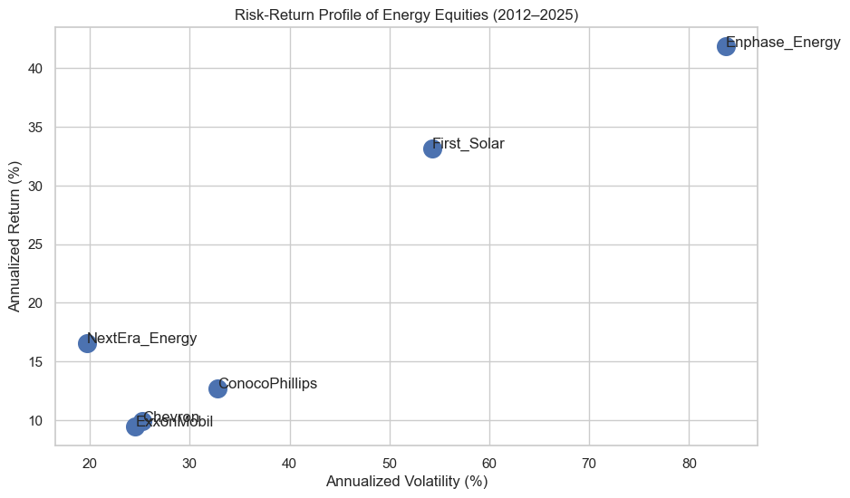

```python
# ============================================================
# Risk vs Return Analysis
# ============================================================

risk_return = pd.DataFrame({
    "Annualized Return":
    stock_returns.mean() * 12 * 100,

    "Annualized Volatility":
    stock_returns.std() * np.sqrt(12) * 100
})

plt.figure(figsize=(10,6))

plt.scatter(
    risk_return["Annualized Volatility"],
    risk_return["Annualized Return"],
    s=200
)

for company in risk_return.index:
    plt.annotate(
        company,
        (
            risk_return.loc[company, "Annualized Volatility"],
            risk_return.loc[company, "Annualized Return"]
        )
    )

plt.xlabel("Annualized Volatility (%)")
plt.ylabel("Annualized Return (%)")

plt.title("Risk-Return Profile of Energy Equities (2012–2025)")

plt.grid(True)

plt.show()
```

Volatility analysis reveals significant differences in risk profiles across the selected energy companies.

Enphase Energy emerged as the most volatile stock in the sample, recording both the highest historical volatility and the highest average rolling volatility. This indicates that Enphase experienced the largest month-to-month price fluctuations throughout the study period. While high volatility can create opportunities for substantial returns, it also exposes investors to greater uncertainty and downside risk.

First Solar ranked as the second most volatile company. Similar to Enphase, its higher volatility reflects the growth-oriented nature of renewable energy investments, where investor expectations, technological innovation, policy developments, and financing conditions can have a significant impact on stock performance.

Among the traditional energy companies, ConocoPhillips exhibited the highest volatility, followed by Chevron and ExxonMobil. Although these firms operate in the oil and gas sector, their volatility levels remained substantially lower than those observed in the renewable energy companies.

NextEra Energy displayed the lowest volatility across the entire sample. This finding is consistent with its position as a large utility-based renewable energy company, whose regulated business operations generally produce more stable cash flows and lower market risk.

Overall, the results highlight a clear risk hierarchy within the energy sector:

1. Enphase Energy — Highest Risk
2. First Solar — High Risk
3. ConocoPhillips — Moderate Risk
4. Chevron — Moderate Risk
5. ExxonMobil — Moderate Risk
6. NextEra Energy — Lowest Risk

These findings suggest that renewable energy equities offered greater growth potential during the study period but often required investors to tolerate substantially higher levels of risk. In contrast, traditional oil and gas companies generally exhibited more stable return behavior, while NextEra Energy provided a unique combination of renewable energy exposure and comparatively lower volatility.

### 8.3 Renewable Energy versus Oil & Gas

A central objective of this project is to compare renewable energy equities with traditional oil & gas companies. While both operate within the broader energy sector, their business models, growth drivers, and sensitivity to economic conditions differ substantially. To facilitate comparison, average returns and volatility measures were calculated for each group.

```python
# ============================================================
# Create Renewable vs Oil & Gas Group Returns
# ============================================================

group_summary = pd.DataFrame(index=stock_returns.index)

group_summary["Renewable_Average_Return"] = (
    stock_returns[renewable_names]
    .mean(axis=1)
)

group_summary["Oil_Gas_Average_Return"] = (
    stock_returns[oil_names]
    .mean(axis=1)
)
```

```python
# ============================================================
# Renewable vs Oil & Gas Comparison
# ============================================================

comparison_df = pd.DataFrame({
    "Group": ["Renewable Energy", "Oil & Gas"],
    "Average Monthly Return (%)": [
        group_summary["Renewable_Average_Return"].mean() * 100,
        group_summary["Oil_Gas_Average_Return"].mean() * 100
    ],
    "Monthly Volatility (%)": [
        group_summary["Renewable_Average_Return"].std() * 100,
        group_summary["Oil_Gas_Average_Return"].std() * 100
    ]
})

comparison_df = comparison_df.round(2)

comparison_df
```

|  | Group | Average Monthly Return (%) | Monthly Volatility (%) |
| --- | --- | --- | --- |
| 0 | Renewable Energy | 2.5400 | 11.3600 |
| 1 | Oil & Gas | 0.8900 | 7.4400 |

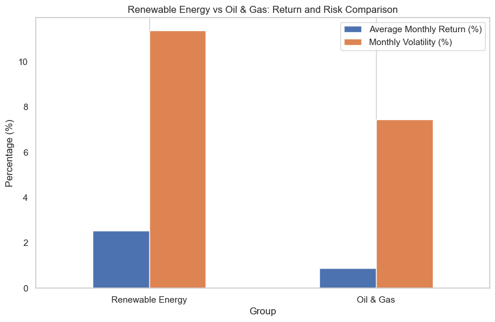

```python
comparison_plot = comparison_df.set_index("Group")

comparison_plot.plot(
    kind="bar",
    figsize=(10,6)
)

plt.title(
    "Renewable Energy vs Oil & Gas: Return and Risk Comparison"
)

plt.ylabel("Percentage (%)")

plt.xticks(rotation=0)

plt.grid(axis="y")

plt.show()
```

The comparison reveals a clear distinction between renewable energy equities and traditional oil & gas companies during the study period.

Renewable energy stocks generated an average monthly return of approximately **2.54%**, substantially exceeding the **0.89%** average monthly return observed among oil & gas companies. This suggests that renewable energy firms offered stronger long-term growth opportunities over the sample period.

The results highlight a classic investment trade-off between risk and reward. Investors seeking higher growth potential may have benefited from renewable energy exposure, but they would also have needed to tolerate substantially higher volatility. In contrast, traditional oil & gas companies provided lower average returns but exhibited more stable return characteristics.

Overall, the findings suggest that renewable energy equities behaved as higher-growth, higher-risk investments, while oil & gas companies demonstrated a more conservative risk-return profile throughout the study period.

### 8.4 Drawdown and Downside Risk Analysis

Returns alone do not fully capture investment risk. Investors are also concerned with how much value may be lost during market downturns. Drawdown analysis measures the percentage decline from a previous peak and provides insight into downside risk and recovery behavior.

```python
# ============================================================
# Maximum Historical Drawdowns
# ============================================================

max_drawdowns = drawdown.min().sort_values()

max_drawdowns
```

```
Ticker
Enphase_Energy   -0.9494
First_Solar      -0.6229
ConocoPhillips   -0.6051
ExxonMobil       -0.5840
Chevron          -0.4066
NextEra_Energy   -0.3735
dtype: float64
```

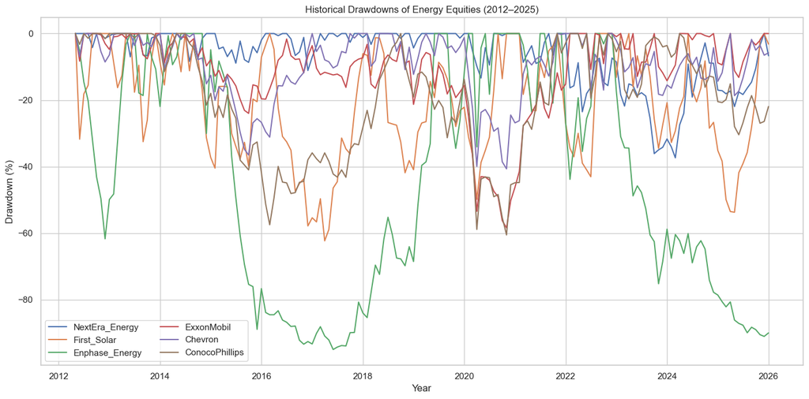

```python
# ============================================================
# Historical Drawdowns Through Time
# ============================================================

plt.figure(figsize=(14,7))

for stock in drawdown.columns:
    plt.plot(
        drawdown.index,
        drawdown[stock] * 100,
        label=stock
    )

plt.title(
    "Historical Drawdowns of Energy Equities (2012–2025)"
)

plt.xlabel("Year")
plt.ylabel("Drawdown (%)")

plt.legend(
    loc="lower left",
    ncol=2
)

plt.grid(True)

plt.tight_layout()
plt.show()
```

While return and volatility metrics describe performance and risk, drawdown analysis provides insight into the actual losses investors may experience during periods of market stress. And therefore the results reveal substantial differences in downside risk across the energy sector.

**Enphase Energy** experienced the deepest drawdown in the sample, falling approximately **94.9% below its previous peak** at its worst point. This indicates that although Enphase generated the highest long-term return profile, investors would have needed to tolerate extremely large temporary losses during adverse market conditions.

**First Solar** also experienced a significant drawdown of approximately **62.3%**, reflecting the higher risk profile often associated with growth-oriented renewable energy companies.

Among the traditional oil and gas companies, **ConocoPhillips**, **ExxonMobil**, and **Chevron** experienced drawdowns ranging from approximately **40% to 60%**. These losses were substantial but generally less severe than those observed among the higher-growth renewable energy firms.

**NextEra Energy** recorded the smallest maximum drawdown at approximately **37.4%**, suggesting that it was the most resilient company in the sample during periods of market stress. This finding is consistent with its lower volatility profile and utility-oriented business model.

Overall, the drawdown analysis reinforces an important investment principle: higher return potential is often accompanied by greater downside risk. While renewable energy companies delivered stronger growth opportunities throughout the study period, they also exposed investors to deeper and more prolonged losses. In contrast, NextEra Energy and several traditional energy companies exhibited greater resilience during market downturns.

These findings demonstrate why investors should evaluate downside risk alongside return and volatility metrics when assessing long-term investment opportunities.

### 8.5 Relationships Between Energy Stocks and Macroeconomic Variables

The final stage of the exploratory analysis investigates how energy-sector performance relates to broader economic conditions. Understanding these relationships helps identify which macroeconomic factors may be associated with energy equity returns.

Variables examined include:

- Federal Funds Rate
- Inflation (CPI)
- GDP
- 10-Year Treasury Yield
- Crude Oil Prices
- S&P 500 Performance

```python
# ============================================================
# Correlation Matrix
# ============================================================

correlation_data = pd.concat([
    stock_returns,
    monthly_returns[["SP500", "Crude_Oil"]],
    fred_monthly
], axis=1).dropna()

correlation_matrix = correlation_data.corr()

correlation_matrix
```

|  | NextEra_Energy | First_Solar | Enphase_Energy | ExxonMobil | Chevron | ConocoPhillips | SP500 | Crude_Oil | FEDFUNDS | CPIAUCSL | GS10 | GDP |
| --- | --- | --- | --- | --- | --- | --- | --- | --- | --- | --- | --- | --- |
| NextEra_Energy | 1.0000 | 0.3702 | 0.1765 | -0.0238 | 0.0630 | -0.1254 | 0.3183 | -0.0108 | -0.0610 | -0.0808 | -0.0826 | -0.0756 |
| First_Solar | 0.3702 | 1.0000 | 0.2456 | 0.1736 | 0.2589 | 0.1276 | 0.4272 | 0.0646 | -0.0090 | 0.0055 | -0.0322 | -0.0066 |
| Enphase_Energy | 0.1765 | 0.2456 | 1.0000 | 0.0708 | 0.2198 | 0.1228 | 0.2050 | 0.0931 | -0.0970 | -0.0999 | -0.1421 | -0.0916 |
| ExxonMobil | -0.0238 | 0.1736 | 0.0708 | 1.0000 | 0.8540 | 0.7915 | 0.5193 | 0.4817 | -0.0313 | 0.0785 | 0.0073 | 0.0734 |
| Chevron | 0.0630 | 0.2589 | 0.2198 | 0.8540 | 1.0000 | 0.8071 | 0.5871 | 0.4516 | -0.0632 | 0.0197 | -0.0487 | 0.0171 |
| ConocoPhillips | -0.1254 | 0.1276 | 0.1228 | 0.7915 | 0.8071 | 1.0000 | 0.4612 | 0.5139 | -0.0819 | 0.0062 | -0.0654 | 0.0016 |
| SP500 | 0.3183 | 0.4272 | 0.2050 | 0.5193 | 0.5871 | 0.4612 | 1.0000 | 0.3443 | 0.0418 | 0.0255 | -0.0128 | 0.0224 |
| Crude_Oil | -0.0108 | 0.0646 | 0.0931 | 0.4817 | 0.4516 | 0.5139 | 0.3443 | 1.0000 | -0.0784 | -0.0105 | -0.1243 | -0.0144 |
| FEDFUNDS | -0.0610 | -0.0090 | -0.0970 | -0.0313 | -0.0632 | -0.0819 | 0.0418 | -0.0784 | 1.0000 | 0.8469 | 0.8579 | 0.8381 |
| CPIAUCSL | -0.0808 | 0.0055 | -0.0999 | 0.0785 | 0.0197 | 0.0062 | 0.0255 | -0.0105 | 0.8469 | 1.0000 | 0.7215 | 0.9945 |
| GS10 | -0.0826 | -0.0322 | -0.1421 | 0.0073 | -0.0487 | -0.0654 | -0.0128 | -0.1243 | 0.8579 | 0.7215 | 1.0000 | 0.6956 |
| GDP | -0.0756 | -0.0066 | -0.0916 | 0.0734 | 0.0171 | 0.0016 | 0.0224 | -0.0144 | 0.8381 | 0.9945 | 0.6956 | 1.0000 |

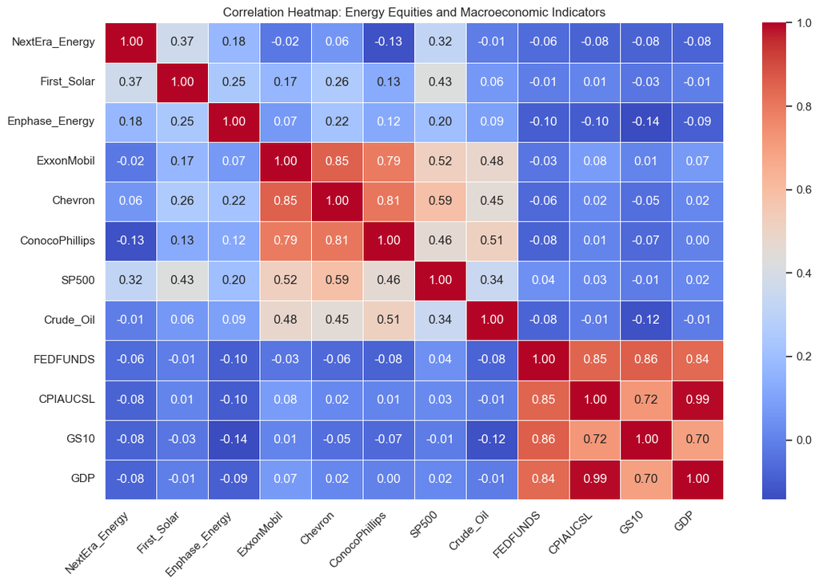

```python
# ============================================================
# Correlation Heatmap
# ============================================================

plt.figure(figsize=(12,8))

sns.heatmap(
    correlation_matrix,
    annot=True,
    cmap="coolwarm",
    fmt=".2f",
    linewidths=0.5
)

plt.title(
    "Correlation Heatmap: Energy Equities and Macroeconomic Indicators"
)

plt.xticks(rotation=45, ha="right")
plt.yticks(rotation=0)

plt.tight_layout()

plt.show()
```

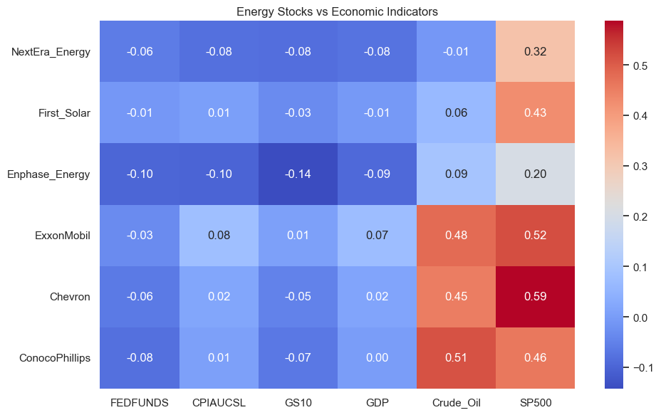

```python
# ============================================================
# Stock vs Macroeconomic Correlations
# ============================================================

macro_vars = [
    "FEDFUNDS",
    "CPIAUCSL",
    "GS10",
    "GDP",
    "Crude_Oil",
    "SP500"
]

stock_macro_corr = correlation_matrix.loc[
    stock_names,
    macro_vars
]

plt.figure(figsize=(10,6))

sns.heatmap(
    stock_macro_corr,
    annot=True,
    cmap="coolwarm",
    fmt=".2f"
)

plt.title(
    "Energy Stocks vs Economic Indicators"
)

plt.tight_layout()
plt.show()
```

The correlation analysis provides insight into how energy equities move relative to one another, broader market conditions, commodity prices, and macroeconomic indicators.

Several important patterns emerge from the results.

Third, crude oil prices exhibit stronger positive relationships with traditional energy companies than with renewable energy firms. This result is consistent with industry expectations because oil and gas company revenues are directly linked to commodity prices.

Fourth, the S&P 500 shows positive correlations with most energy equities, indicating that broader market conditions play an important role in energy-sector performance.

Finally, macroeconomic variables such as interest rates, inflation, GDP, and Treasury yields show varying degrees of association across companies. While some relationships appear relatively weak, others suggest that changes in economic conditions may influence energy-sector performance through financing costs, economic growth expectations, and investor sentiment.

Overall, the correlation analysis indicates that renewable energy and traditional oil & gas companies are not driven by identical factors. This distinction supports the broader objective of the project, which is to evaluate how different economic and market conditions may create investment opportunities across the energy sector.

## **9. Performance Analysis**

While previous sections focused on return distributions, volatility, downside risk, and market relationships, this section evaluates the overall investment performance of the selected energy equities.

The primary objective is to assess how renewable energy companies and traditional oil & gas companies performed throughout the study period and identify which investments generated the strongest long-term value creation.

Performance is evaluated from three perspectives:

1. Growth and wealth creation.
2. Risk-adjusted performance.
3. Relative performance versus market benchmarks.

Together, these analyses provide a more complete picture of investment attractiveness than returns alone.

### 9.1 Growth of a Hypothetical $100 Investment

To compare long-term performance across companies, all stocks were normalized to a common starting value of $100. This approach removes differences in stock prices and allows performance to be evaluated on an equal basis. The resulting chart illustrates how a hypothetical investment would have grown over the study period.

```python
# ============================================================
# Growth of a $100 Investment
# ============================================================

growth_index = (
    (1 + stock_returns)
    .cumprod()
    * 100
)

growth_index.head()
```

| Ticker Date | NextEra_Energy | First_Solar | Enphase_Energy | ExxonMobil | Chevron | ConocoPhillips |
| --- | --- | --- | --- | --- | --- | --- |
| 2012-05-31 | 102.4820 | 68.2609 | 94.7802 | 91.6975 | 93.0882 | 96.7433 |
| 2012-06-30 | 107.9245 | 81.8478 | 85.4396 | 99.7910 | 99.8963 | 103.6429 |
| 2012-07-31 | 111.2025 | 84.4565 | 79.8077 | 101.2836 | 103.7596 | 102.1598 |
| 2012-08-31 | 106.5062 | 108.6413 | 68.1319 | 102.4700 | 107.0528 | 106.5697 |
| 2012-09-30 | 111.2848 | 120.3804 | 56.8681 | 107.3412 | 111.2524 | 107.3015 |

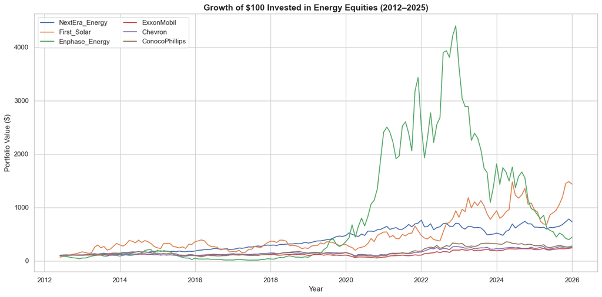

```python
# ============================================================
# Plot Growth of $100
# ============================================================

plt.figure(figsize=(14,7))

for stock in growth_index.columns:
    plt.plot(
        growth_index.index,
        growth_index[stock],
        label=stock
    )

plt.title(
    "Growth of $100 Invested in Energy Equities (2012–2025)",
    fontsize=14,
    fontweight="bold"
)

plt.xlabel("Year")
plt.ylabel("Portfolio Value ($)")

plt.legend(
    loc="upper left",
    ncol=2
)

plt.grid(True)

plt.tight_layout()

plt.show()
```

The growth-of-investment analysis provides a clear comparison of long-term wealth creation across renewable energy and traditional oil & gas companies between 2012 and 2025.

The most striking result is the performance of **Enphase Energy**, which significantly outperformed all other companies during the study period. A hypothetical 100 dollar investment in Enphase grew to more than $2,500 at its peak, highlighting the extraordinary growth experienced by the company during the rapid expansion of the renewable energy sector. However, the chart also shows substantial declines after its peak, demonstrating the high volatility and risk associated with achieving those returns.

**NextEra Energy** delivered strong and relatively consistent long-term growth compared to most other companies in the sample. Although its returns did not reach the extreme levels observed for Enphase, the company exhibited a much smoother growth trajectory, reflecting its more stable business model and lower risk profile.

**Chevron** and **ConocoPhillips** also produced positive long-term growth, although their performance was generally more moderate compared to the highest-performing renewable energy companies.

Overall, the analysis highlights two important investment insights. First, renewable energy companies provided the greatest long-term growth opportunities during the study period, particularly Enphase Energy. Second, those higher returns were accompanied by substantially greater volatility and larger fluctuations in portfolio value. Traditional oil and gas companies generated lower overall returns but generally exhibited more stable performance patterns.

From an investor's perspective, the chart illustrates the trade-off between growth potential and risk. Investors seeking maximum long-term appreciation would have benefited most from high-growth renewable energy companies, while investors prioritizing stability may have preferred larger and more established firms such as NextEra Energy, ExxonMobil, or Chevron.

### 9.2 Renewable Energy versus Oil & Gas Performance

While individual companies may perform differently, it is also important to evaluate the broader sectors they represent. This analysis compares the cumulative performance of renewable energy equities against traditional oil & gas companies using equally weighted sector portfolios.

```python
# ============================================================
# Create Sector Portfolios
# ============================================================

sector_returns = pd.DataFrame({
    "Renewable_Energy":
        stock_returns[renewable_names].mean(axis=1),

    "Oil_Gas":
        stock_returns[oil_names].mean(axis=1)
})

sector_growth = (
    (1 + sector_returns)
    .cumprod()
    * 100
)

sector_growth.head()
```

| Date | Renewable_Energy | Oil_Gas |
| --- | --- | --- |
| 2012-05-31 | 88.5077 | 93.8430 |
| 2012-06-30 | 93.0393 | 101.1226 |
| 2012-07-31 | 92.9255 | 102.4480 |
| 2012-08-31 | 95.9557 | 105.4060 |
| 2012-09-30 | 95.5590 | 108.6959 |

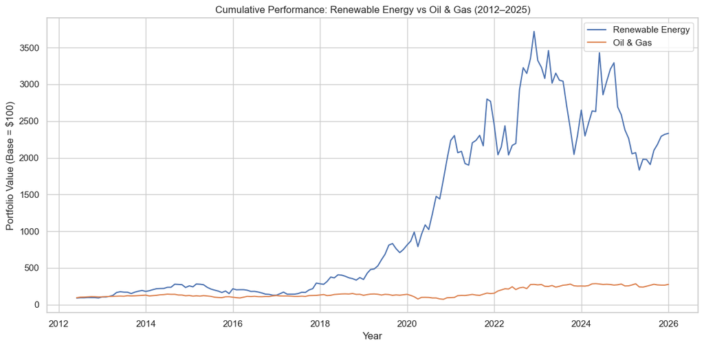

```python
# ============================================================
# Plot Sector Performance
# ============================================================

plt.figure(figsize=(12,6))

plt.plot(
    sector_growth.index,
    sector_growth["Renewable_Energy"],
    label="Renewable Energy"
)

plt.plot(
    sector_growth.index,
    sector_growth["Oil_Gas"],
    label="Oil & Gas"
)

plt.title(
    "Cumulative Performance: Renewable Energy vs Oil & Gas (2012–2025)"
)

plt.xlabel("Year")
plt.ylabel("Portfolio Value (Base = $100)")

plt.legend()

plt.grid(True)

plt.tight_layout()

plt.show()
```

The sector-level analysis reveals a substantial performance gap between renewable energy equities and traditional oil & gas companies over the study period from 2012 to 2025.

At the beginning of the sample period, both sectors exhibited relatively similar performance, with a hypothetical investment of $100 remaining close to its initial value through much of the 2015–2017 period. However, beginning around 2018, the renewable energy sector started to significantly outperform the oil & gas sector.

Despite this strong performance, the renewable energy sector also exhibited considerably higher volatility. Following its peak, the portfolio experienced several significant declines, demonstrating that higher returns were accompanied by greater risk and larger fluctuations in portfolio value.

In contrast, the oil & gas portfolio followed a more stable growth trajectory throughout the study period. While it did not achieve the same level of appreciation as renewable energy stocks, it exhibited smaller fluctuations and more consistent performance, particularly during periods of elevated energy prices and strong demand for fossil fuels.

By the end of the study period, the renewable energy portfolio remained substantially above its starting value and significantly outperformed the oil & gas portfolio in terms of cumulative growth. However, the journey to achieve those returns involved considerably greater volatility and downside risk.

Overall, the results suggest that renewable energy equities offered superior long-term growth potential during the study period, while traditional oil & gas companies provided a more stable but lower-growth investment profile. This finding reinforces one of the central themes of the project: higher return opportunities often come with higher levels of uncertainty and risk.

### 9.3 Risk-Adjusted Performance

Returns alone do not fully measure investment success. Professional investors evaluate how much return was generated relative to the amount of risk required to achieve it. To assess risk-adjusted performance, a simplified Sharpe-style measure is calculated by dividing average return by return volatility.

```python
# ============================================================
# Risk-Adjusted Performance
# ============================================================

risk_adjusted = pd.DataFrame({
    "Average Return":
        stock_returns.mean(),

    "Volatility":
        stock_returns.std()
})

risk_adjusted["Return_to_Risk"] = (
    risk_adjusted["Average Return"]
    /
    risk_adjusted["Volatility"]
)

risk_adjusted = risk_adjusted.sort_values(
    "Return_to_Risk",
    ascending=False
)

risk_adjusted
```

| Ticker | Average Return | Volatility | Return_to_Risk |
| --- | --- | --- | --- |
| NextEra_Energy | 0.0138 | 0.0569 | 0.2425 |
| First_Solar | 0.0276 | 0.1567 | 0.1765 |
| Enphase_Energy | 0.0349 | 0.2415 | 0.1445 |
| Chevron | 0.0082 | 0.0730 | 0.1130 |
| ConocoPhillips | 0.0106 | 0.0946 | 0.1118 |
| ExxonMobil | 0.0079 | 0.0709 | 0.1111 |

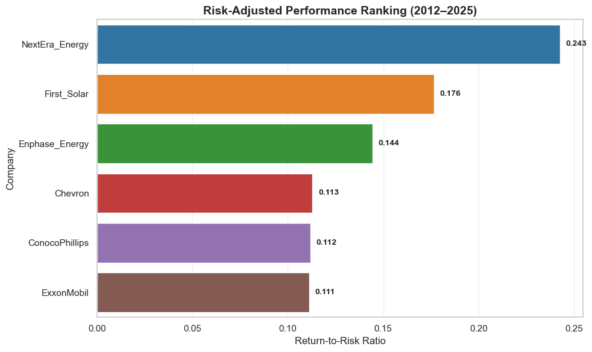

```python
plt.figure(figsize=(10,6))

colors = [
    "#1f77b4",  # NextEra Energy - Blue
    "#ff7f0e",  # First Solar - Orange
    "#2ca02c",  # Enphase Energy - Green
    "#d62728",  # Chevron - Red
    "#9467bd",  # ExxonMobil - Purple
    "#8c564b"   # ConocoPhillips - Brown
]

ax = sns.barplot(
    x=risk_adjusted["Return_to_Risk"],
    y=risk_adjusted.index,
    palette=colors
)

# Add values at end of bars
for i, value in enumerate(risk_adjusted["Return_to_Risk"]):
    ax.text(
        value + 0.003,
        i,
        f"{value:.3f}",
        va="center",
        fontsize=10,
        fontweight="bold"
    )

plt.title(
    "Risk-Adjusted Performance Ranking (2012–2025)",
    fontsize=14,
    fontweight="bold"
)

plt.xlabel(
    "Return-to-Risk Ratio",
    fontsize=12
)

plt.ylabel(
    "Company",
    fontsize=12
)

plt.grid(axis="x", alpha=0.3)

plt.tight_layout()

plt.show()
```

Risk-adjusted performance evaluates how efficiently each company converted risk into return throughout the study period. While total returns are important, investors must also consider the level of volatility required to achieve those returns.

Despite producing the highest average returns among all companies, **Enphase Energy** ranked third. Its significantly higher volatility reduced its risk-adjusted performance, demonstrating that exceptional returns do not always translate into superior investment efficiency.

Overall, the analysis highlights an important distinction between absolute performance and investment efficiency. Renewable energy companies delivered the strongest growth opportunities during the study period, but NextEra Energy emerged as the most attractive company from a risk-adjusted perspective. The findings suggest that investors seeking long-term wealth creation should evaluate both return potential and risk exposure rather than focusing solely on raw returns.

### 9.4 Performance Analysis Summary

The performance analysis reveals significant differences in the return, risk, and investment characteristics of renewable energy and traditional oil & gas equities during the study period.

Among the renewable energy companies, Enphase Energy generated the strongest long-term capital appreciation, demonstrating the substantial growth potential that can exist within emerging segments of the energy transition. However, this exceptional performance was accompanied by extremely high volatility and the deepest drawdowns observed in the sample, highlighting the significant risks associated with high-growth investments.

NextEra Energy emerged as the strongest performer from a risk-adjusted perspective. While its total returns were lower than those of Enphase Energy, it consistently delivered attractive returns with substantially lower volatility and drawdown risk. This combination resulted in the highest return-to-risk ratio among all companies analyzed, suggesting a more efficient balance between growth and risk.

Within the traditional energy sector, ExxonMobil, Chevron, and ConocoPhillips produced more moderate but generally more stable returns. These companies benefited from periods of rising energy prices and strong commodity markets, but their overall long-term growth remained below that of the leading renewable energy companies.

At the sector level, renewable energy equities significantly outperformed oil & gas equities in cumulative return terms. The sector experienced rapid growth during periods of increased investment in clean energy technologies and favorable market sentiment. However, this outperformance came at the cost of substantially greater volatility and larger drawdowns. In contrast, oil & gas equities delivered more stable but slower long-term growth.

The analysis also demonstrates that evaluating investment opportunities solely on total return can be misleading. Investors must consider volatility, downside risk, and risk-adjusted performance when assessing long-term investment attractiveness. Companies generating the highest returns are not necessarily those providing the most efficient investment outcomes.

Overall, the findings suggest that renewable energy equities offered superior long-term growth opportunities throughout the study period, while traditional energy companies provided greater stability and lower risk. These results establish the foundation for the next stage of the analysis, where market, commodity, and macroeconomic indicators are evaluated to determine whether specific economic conditions may help identify favorable buying opportunities within the energy sector.

## **10. Market Regime Analysis**

Financial markets do not operate under a single set of economic conditions. Instead, market behavior changes across different economic environments, often referred to as market regimes.

A market regime represents a period characterized by a particular combination of economic, monetary, and market conditions. Examples include periods of low interest rates, rising inflation, strong commodity prices, or broad market weakness.

Understanding market regimes is important because investment performance is often highly dependent on the environment in which it occurs. A strategy that performs well during a low-interest-rate environment may perform very differently during periods of monetary tightening or economic uncertainty.

The objective of this section is to examine how renewable energy and traditional oil & gas equities behaved under different market conditions. Rather than focusing solely on overall performance, this analysis investigates whether certain economic environments were associated with stronger or weaker stock returns.

Three market regimes are examined:

1. Interest Rate Regimes
2. Oil Price Regimes
3. Broad Market Regimes

Together, these analyses provide insight into the economic conditions that may create favorable environments for different segments of the energy sector.

### 10.1 Interest Rate Regimes

Interest rates influence investment decisions, borrowing costs, corporate financing, and valuation models.

Renewable energy companies are often considered more sensitive to interest-rate changes because many renewable projects require significant upfront capital investment and long-term financing. Higher interest rates increase financing costs and may reduce the present value of future cash flows.

To evaluate this relationship, the sample period is divided into:

- Low Interest Rate Regime
- High Interest Rate Regime

using the median Federal Funds Rate as the classification threshold.

```python
# ============================================================
# Create Interest Rate Regimes
# ============================================================

interest_rate_regime = pd.DataFrame(index=combined_data.index)

interest_rate_regime["Rate_Regime"] = np.where(
    combined_data["FEDFUNDS"] >= combined_data["FEDFUNDS"].median(),
    "High Rate",
    "Low Rate"
)
```

```python
# ============================================================
# Average Returns by Interest Rate Regime
# ============================================================

rate_regime_returns = (
    stock_returns
    .join(interest_rate_regime["Rate_Regime"])
    .groupby("Rate_Regime")[stock_names]
    .mean()
    .T
)

rate_regime_returns
```

| Rate_Regime | High Rate | Low Rate |
| --- | --- | --- |
| NextEra_Energy | 0.0138 | 0.0138 |
| First_Solar | 0.0268 | 0.0285 |
| Enphase_Energy | 0.0489 | 0.0205 |
| ExxonMobil | -0.0002 | 0.0162 |
| Chevron | -0.0002 | 0.0168 |
| ConocoPhillips | 0.0004 | 0.0211 |

```python
# ============================================================
# Interest Rate Regime Comparison Table
# ============================================================

rate_comparison = rate_regime_returns.copy()

rate_comparison["Difference"] = (
    rate_comparison["High Rate"]
    - rate_comparison["Low Rate"]
)

rate_comparison["Relative Change (%)"] = (
    (
        rate_comparison["High Rate"]
        - rate_comparison["Low Rate"]
    )
    /
    abs(rate_comparison["Low Rate"])
) * 100

rate_comparison = rate_comparison.sort_values(
    "Relative Change (%)",
    ascending=False
)

rate_comparison.round(4)
```

| Rate_Regime | High Rate | Low Rate | Difference | Relative Change (%) |
| --- | --- | --- | --- | --- |
| Enphase_Energy | 0.0489 | 0.0205 | 0.0284 | 138.4206 |
| NextEra_Energy | 0.0138 | 0.0138 | 0.0001 | 0.4530 |
| First_Solar | 0.0268 | 0.0285 | -0.0017 | -5.9466 |
| ConocoPhillips | 0.0004 | 0.0211 | -0.0207 | -98.3181 |
| Chevron | -0.0002 | 0.0168 | -0.0170 | -100.9050 |
| ExxonMobil | -0.0002 | 0.0162 | -0.0164 | -101.5108 |

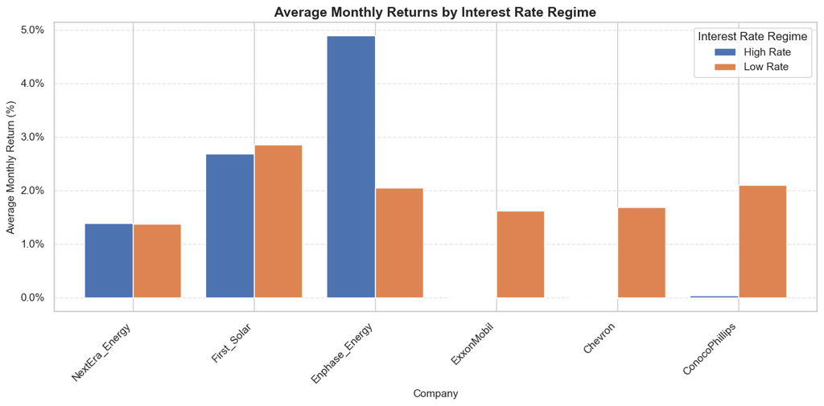

```python
# ============================================================
# Performance by Interest Rate Regime
# ============================================================

ax = rate_regime_returns.plot(
    kind="bar",
    figsize=(12, 6),
    width=0.8
)

plt.title(
    "Average Monthly Returns by Interest Rate Regime",
    fontsize=14,
    fontweight="bold"
)

plt.xlabel(
    "Company",
    fontsize=11
)

plt.ylabel(
    "Average Monthly Return (%)",
    fontsize=11
)

# Convert y-axis to percentages
ax.yaxis.set_major_formatter(
    plt.FuncFormatter(lambda y, _: f"{y:.1%}")
)

plt.xticks(
    rotation=45,
    ha="right"
)

plt.legend(
    title="Interest Rate Regime",
    frameon=True
)

plt.grid(
    axis="y",
    linestyle="--",
    alpha=0.5
)

plt.tight_layout()

plt.show()
```

The interest rate regime analysis reveals one of the most important findings of the study. Energy-sector performance differed substantially depending on whether the market was operating in a high-interest-rate or low-interest-rate environment.

The magnitude of these differences suggests that renewable energy companies were not negatively impacted by higher interest rates to the extent commonly assumed. Although higher borrowing costs are often viewed as a headwind for capital-intensive renewable energy projects, the historical data indicates that broader growth trends, technological adoption, and investor demand may have been more influential drivers of performance during the study period.

Traditional oil & gas companies exhibited the opposite pattern. ExxonMobil, Chevron, and ConocoPhillips all produced higher average monthly returns during low-interest-rate environments. The largest negative sensitivity to higher rates was observed in Chevron and ConocoPhillips, whose returns declined substantially when interest rates increased.

#### Regime Winners and Losers

Based on historical performance:

**Best-performing companies during low-rate environments:**

- Chevron
- ConocoPhillips
- ExxonMobil

#### Market Intelligence Insight

From a market intelligence perspective, the findings indicate that interest-rate conditions may provide useful context when evaluating investment opportunities in the energy sector. Rather than treating all energy companies as a single group, investors should recognize that different segments of the sector respond differently to changing monetary policy environments.

These findings provide evidence that macroeconomic conditions can help explain variations in stock performance and may contribute to the development of a broader framework for identifying potentially favorable investment environments.

### 10.2 Oil Price Regimes

Crude oil prices are among the most important drivers of energy-sector performance.

Traditional oil and gas companies are directly exposed to commodity price movements because revenues and profitability are strongly influenced by oil prices. Renewable energy companies may also be indirectly affected, as changes in fossil fuel prices can alter the relative attractiveness of alternative energy sources.

To examine this relationship, the sample period is divided into:

- High Oil Price Regime
- Low Oil Price Regime

using the median crude oil price over the study period.

```python
# ============================================================
# Oil Price Regimes
# ============================================================

median_oil = monthly_prices["Crude_Oil"].median()

oil_regime = pd.DataFrame(index=monthly_prices.index)

oil_regime["Oil_Regime"] = np.where(
    monthly_prices["Crude_Oil"] <= median_oil,
    "Low Oil",
    "High Oil"
)

oil_regime_returns = pd.concat(
    [
        stock_returns,
        oil_regime["Oil_Regime"]
    ],
    axis=1
)

oil_summary = (
    oil_regime_returns
    .groupby("Oil_Regime")[stock_names]
    .mean()
    .T
)

oil_summary
```

| Oil_Regime | High Oil | Low Oil |
| --- | --- | --- |
| NextEra_Energy | 0.0099 | 0.0177 |
| First_Solar | 0.0326 | 0.0228 |
| Enphase_Energy | 0.0071 | 0.0620 |
| ExxonMobil | 0.0173 | -0.0013 |
| Chevron | 0.0143 | 0.0024 |
| ConocoPhillips | 0.0216 | -0.0002 |

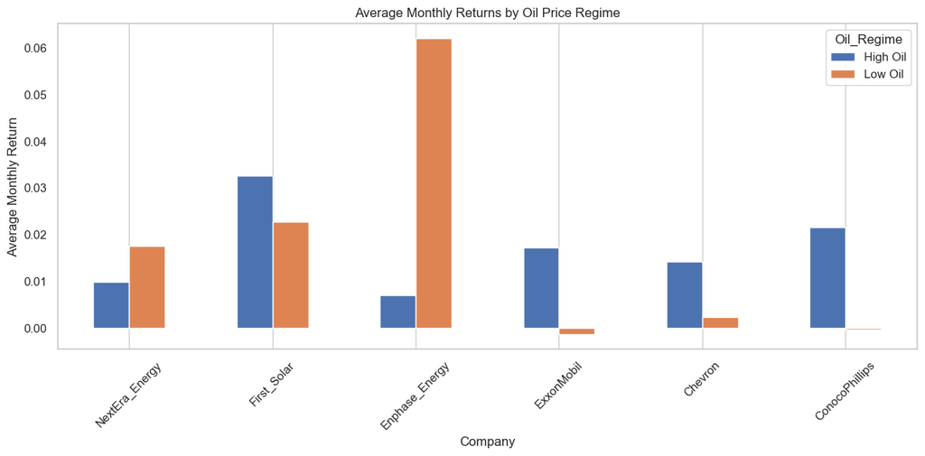

```python
oil_summary.plot(
    kind="bar",
    figsize=(12,6)
)

plt.title(
    "Average Monthly Returns by Oil Price Regime"
)

plt.xlabel("Company")
plt.ylabel("Average Monthly Return")

plt.xticks(rotation=45)

plt.grid(axis="y")

plt.tight_layout()

plt.show()
```

The oil price regime analysis reveals a clear separation between renewable energy companies and traditional oil & gas firms.

These results suggest that renewable energy companies may benefit when fossil fuel prices are relatively subdued, potentially because investors become more focused on long-term growth opportunities, technological innovation, and the transition toward alternative energy sources.

In contrast, the traditional oil & gas companies demonstrated the opposite behavior. ExxonMobil, Chevron, and ConocoPhillips all generated substantially stronger returns during high-oil-price environments. This relationship is consistent with expectations, as higher crude oil prices generally improve revenue, profitability, and cash flow for upstream and integrated energy producers.

#### Regime Winners and Losers

**Most favored during high-oil-price environments:**

- ConocoPhillips
- ExxonMobil
- Chevron

#### Market Intelligence Insight

The findings indicate that oil-price conditions represent an important market regime within the energy sector. Renewable energy companies and traditional oil & gas firms respond differently to commodity-price environments, suggesting that investors should consider oil-market conditions when evaluating sector allocation decisions.

Rather than viewing energy as a single sector, the results support the idea that renewable and traditional energy companies operate under distinct economic drivers and may perform best under different commodity-price regimes.

```python
oil_difference = (
    oil_summary["High Oil"]
    -
    oil_summary["Low Oil"]
).sort_values()
```

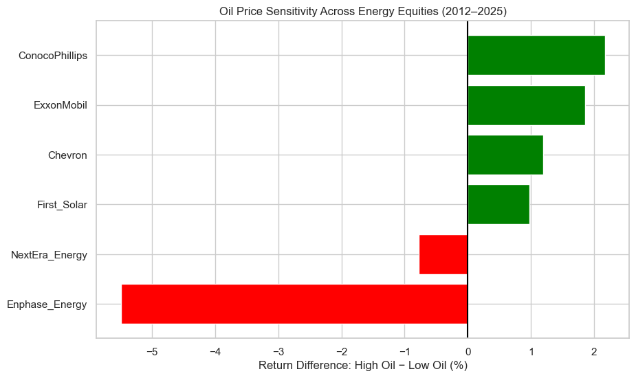

```python
plt.figure(figsize=(10,6))

colors = [
    "red" if x < 0 else "green"
    for x in oil_difference
]

plt.barh(
    oil_difference.index,
    oil_difference.values * 100,
    color=colors
)

plt.axvline(0,color="black")

plt.title(
    "Oil Price Sensitivity Across Energy Equities (2012–2025)"
)

plt.xlabel(
    "Return Difference: High Oil − Low Oil (%)"
)

plt.show()
```

The analysis reveals a clear divergence between renewable energy and traditional oil & gas companies. Renewable energy equities generally generated stronger returns during low-oil-price environments, while oil & gas companies benefited significantly from high-oil-price regimes. Enphase Energy exhibited the strongest negative sensitivity to higher oil prices, whereas ConocoPhillips demonstrated the greatest positive sensitivity.

### 10.3 Broad Market Regimes

Energy companies operate within the broader financial market and may be affected by changes in overall investor sentiment and economic expectations.

To evaluate market sensitivity, months are classified as:

- Positive Market Regime
- Negative Market Regime

based on monthly S&P 500 returns.

This analysis helps determine which companies perform best during favorable market environments and which demonstrate resilience during market downturns.

```python
# ============================================================
# Market Regimes
# ============================================================

market_regime = pd.DataFrame(index=monthly_returns.index)

market_regime["Market_Regime"] = np.where(
    monthly_returns["SP500"] >= 0,
    "Positive Market",
    "Negative Market"
)

market_regime_returns = pd.concat(
    [
        stock_returns,
        market_regime["Market_Regime"]
    ],
    axis=1
)

market_summary = (
    market_regime_returns
    .groupby("Market_Regime")[stock_names]
    .mean()
    .T
)

market_summary
```

| Market_Regime | Negative Market | Positive Market |
| --- | --- | --- |
| NextEra_Energy | -0.0111 | 0.0251 |
| First_Solar | -0.0558 | 0.0653 |
| Enphase_Energy | 0.0019 | 0.0498 |
| ExxonMobil | -0.0324 | 0.0260 |
| Chevron | -0.0398 | 0.0299 |
| ConocoPhillips | -0.0361 | 0.0316 |

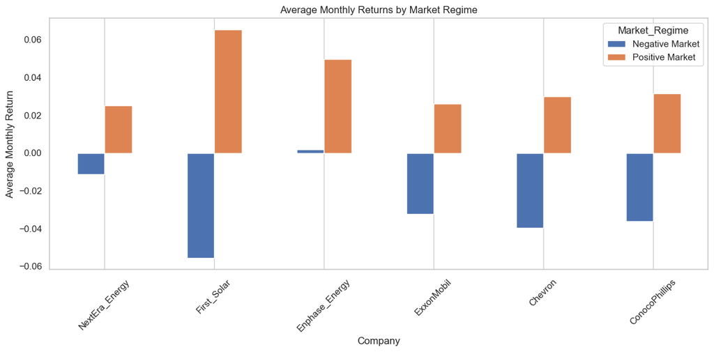

```python
market_summary.plot(
    kind="bar",
    figsize=(12,6)
)

plt.title(
    "Average Monthly Returns by Market Regime"
)

plt.xlabel("Company")
plt.ylabel("Average Monthly Return")

plt.xticks(rotation=45)

plt.grid(axis="y")

plt.tight_layout()

plt.show()
```

```python
market_spread = (
    market_summary["Positive Market"]
    -
    market_summary["Negative Market"]
)

market_spread.sort_values()
```

```
NextEra_Energy   0.0361
Enphase_Energy   0.0478
ExxonMobil       0.0584
ConocoPhillips   0.0677
Chevron          0.0697
First_Solar      0.1210
dtype: float64
```

The market regime analysis evaluates how energy-sector equities perform during periods of positive and negative overall market conditions, using monthly S&P 500 returns as a proxy for market sentiment.

Enphase Energy also demonstrated the strongest downside resilience among all companies in the analysis. During negative market environments, Enphase recorded the smallest average decline, suggesting that it was relatively more resistant to broader market weakness over the study period. NextEra Energy displayed similar defensive characteristics, experiencing smaller losses than most other companies during declining markets.

The traditional oil & gas companies exhibited lower upside participation and larger average losses during negative market periods. Chevron and ConocoPhillips experienced some of the largest declines during weak market environments, indicating greater sensitivity to adverse market conditions.

### Market Intelligence Insight

The findings suggest that market conditions play a significant role in energy-sector performance. Renewable energy companies, particularly Enphase Energy and First Solar, demonstrated stronger participation during rising markets, while Enphase and NextEra Energy showed comparatively better resilience during market downturns.

From a portfolio construction perspective, understanding market-regime behavior may help investors identify which companies are more growth-oriented and which may provide stronger downside protection under changing market conditions.

### 10.4 Market Regime Analysis Summary

The market regime analysis provides a broader perspective on how energy equities respond to changing economic and market environments. Rather than evaluating stock performance in isolation, this analysis examines how returns vary across different interest-rate conditions, oil-price regimes, and overall market environments.

Collectively, these findings suggest that energy-sector performance is shaped by the interaction of company fundamentals, commodity markets, monetary policy, and broader investor sentiment. The results also highlight that renewable energy and traditional oil & gas companies should not be viewed as a single homogeneous sector, as each group responds differently to changing economic conditions.

From a market intelligence perspective, understanding these regime dynamics can help investors, analysts, and decision-makers identify environments that have historically been associated with stronger performance and more favorable risk-return characteristics.

## **11. Macroeconomic Sensitivity Analysis**

After evaluating performance across different market regimes, the next step is to examine how sensitive each energy equity is to broader macroeconomic and market variables.

While market regime analysis shows how companies perform under specific environments, macroeconomic sensitivity analysis helps identify which external factors are most closely associated with each company's stock returns.

This section focuses on answering three key questions:

1. Which macroeconomic and market variables are most strongly associated with energy stock returns?
2. Do renewable energy companies and oil & gas companies respond differently to macroeconomic conditions?
3. Which companies appear most sensitive to changes in the broader economic environment?

The analysis includes the following explanatory variables:

- **S&P 500 Returns** — proxy for broad equity-market sentiment.
- **Crude Oil Returns** — proxy for energy commodity conditions.
- **Federal Funds Rate Change** — captures shifts in monetary policy.
- **Inflation Rate (CPI Growth)** — captures changes in inflationary pressures.
- **10-Year Treasury Yield Change** — captures movements in long-term interest rates.
- **GDP Growth Rate** — captures changes in economic growth conditions.

This section uses correlation-based analysis to measure historical relationships between energy equity returns and macroeconomic indicators. Correlation does not prove causation, but it provides useful evidence about which variables tend to move together over time.

### 11.1 Build the Macroeconomic Sensitivity Dataset

```python
# ============================================================
# Build Macroeconomic Sensitivity Dataset
# ============================================================

# Combine stock returns, market returns, crude oil returns, and macroeconomic indicators.
# This dataset will be used to analyze how energy equities relate to broader
# market and economic variables.

macro_sensitivity_data = pd.concat(
    [
        stock_returns,
        monthly_returns[["SP500", "Crude_Oil"]],
        macro_features
    ],
    axis=1
).dropna()
```

### 11.2 Focused Stock-versus-Macro Correlation Matrix

```python
# ============================================================
# Focused Stock-versus-Macro Correlation Matrix
# ============================================================

# Define macroeconomic and market variables of interest
macro_variables = [
    "SP500",
    "Crude_Oil",
    "FEDFUNDS_Change",
    "CPI_Inflation",
    "GS10_Change",
    "GDP_Growth"
]
# Calculate full correlation matrix
full_macro_corr = macro_sensitivity_data.corr()

# Extract only stock returns versus macro/market variables
stock_macro_corr = full_macro_corr.loc[
    stock_names,
    macro_variables
]

stock_macro_corr
```

|  | SP500 | Crude_Oil | FEDFUNDS_Change | CPI_Inflation | GS10_Change | GDP_Growth |
| --- | --- | --- | --- | --- | --- | --- |
| NextEra_Energy | 0.3183 | -0.0108 | 0.0771 | -0.0475 | -0.2611 | 0.1492 |
| First_Solar | 0.4272 | 0.0646 | 0.1429 | -0.0862 | -0.1156 | 0.0281 |
| Enphase_Energy | 0.2050 | 0.0931 | 0.0768 | 0.0097 | -0.1349 | -0.0776 |
| ExxonMobil | 0.5193 | 0.4817 | 0.1565 | 0.1737 | 0.1963 | -0.0755 |
| Chevron | 0.5871 | 0.4516 | 0.0711 | 0.1179 | 0.1376 | -0.1404 |
| ConocoPhillips | 0.4612 | 0.5139 | 0.1133 | 0.1411 | 0.2281 | -0.1773 |

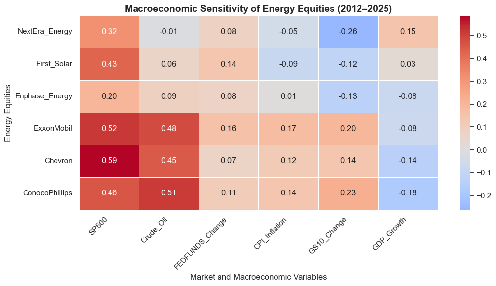

```python
# ============================================================
# Heatmap: Stock-versus-Macro Sensitivity
# ============================================================

plt.figure(figsize=(11, 6))

sns.heatmap(
    stock_macro_corr,
    annot=True,
    cmap="coolwarm",
    fmt=".2f",
    linewidths=0.5,
    center=0
)

plt.title(
    "Macroeconomic Sensitivity of Energy Equities (2012–2025)",
    fontsize=14,
    fontweight="bold"
)

plt.xlabel("Market and Macroeconomic Variables")
plt.ylabel("Energy Equities")

plt.xticks(rotation=45, ha="right")
plt.yticks(rotation=0)

plt.tight_layout()
plt.show()
```

The focused correlation matrix shows how each energy stock relates to broader market and macroeconomic variables.

The S&P 500 also shows positive correlations with most energy equities, suggesting that broad equity-market sentiment remains an important driver of energy stock performance. Chevron, ExxonMobil, and ConocoPhillips appear particularly connected to broader market movements.

Renewable energy companies show weaker relationships with crude oil compared with the oil & gas firms. This suggests that their performance may be influenced more by company-specific factors, growth expectations, technology adoption, and investor sentiment than by crude oil prices directly.

The transformed macroeconomic variables reveal that changes in economic conditions generally exhibit weaker direct relationships with stock returns than broader market and commodity-price movements. While interest-rate changes, inflation dynamics, Treasury-yield movements, and GDP growth may influence energy-sector performance, their effects appear more indirect and less immediate than those of crude oil prices and overall market sentiment.

This finding suggests that equity-market conditions and commodity-market dynamics remain the dominant short-term drivers of energy-stock performance, while macroeconomic fundamentals may operate through longer-term transmission mechanisms.

Overall, the table supports the idea that renewable energy and oil & gas companies should not be treated as one identical sector. Oil & gas firms show clearer sensitivity to crude oil and broad market performance, while renewable energy companies display more varied and company-specific relationships.

### 11.3 Identify the Strongest Macro Driver for Each Company

```python
# ============================================================
# Identify Strongest Macro Driver for Each Company
# ============================================================

# Use absolute correlation to identify the strongest relationship,
# regardless of whether the direction is positive or negative.
strongest_macro_driver = pd.DataFrame(index=stock_macro_corr.index)

strongest_macro_driver["Strongest_Driver"] = (
    stock_macro_corr.abs().idxmax(axis=1)
)

strongest_macro_driver["Correlation_Value"] = [
    stock_macro_corr.loc[stock, strongest_macro_driver.loc[stock, "Strongest_Driver"]]
    for stock in strongest_macro_driver.index
]

strongest_macro_driver = strongest_macro_driver.sort_values(
    "Correlation_Value",
    ascending=False
)

strongest_macro_driver
```

|  | Strongest_Driver | Correlation_Value |
| --- | --- | --- |
| Chevron | SP500 | 0.5871 |
| ExxonMobil | SP500 | 0.5193 |
| ConocoPhillips | Crude_Oil | 0.5139 |
| First_Solar | SP500 | 0.4272 |
| NextEra_Energy | SP500 | 0.3183 |
| Enphase_Energy | SP500 | 0.2050 |

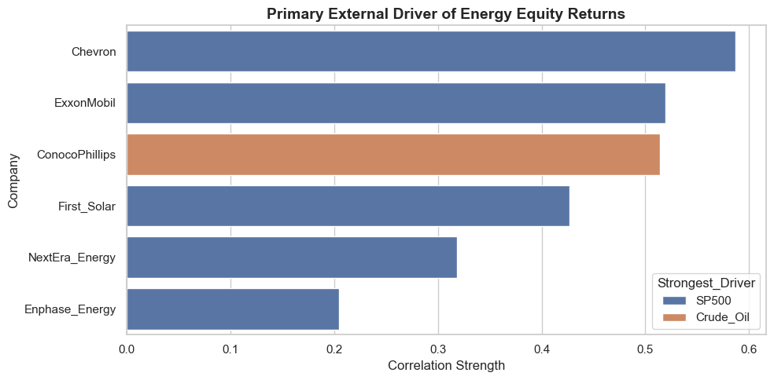

```python
plt.figure(figsize=(10,5))

sns.barplot(
    data=strongest_macro_driver.reset_index(),
    x="Correlation_Value",
    y=strongest_macro_driver.index,
    hue="Strongest_Driver",
    dodge=False
)

plt.title(
    "Primary External Driver of Energy Equity Returns",
    fontsize=14,
    fontweight="bold"
)

plt.xlabel("Correlation Strength")
plt.ylabel("Company")

plt.tight_layout()
plt.show()
```

The strongest-driver analysis identifies the single market or macroeconomic variable that exhibits the highest historical relationship with each company's monthly returns. Rather than evaluating multiple correlations simultaneously, this approach highlights the factor that appears most closely associated with stock performance over the study period.

#### Key Findings

These findings suggest that overall market sentiment and investor risk appetite play an important role in explaining the performance of both renewable energy and traditional energy equities. Companies with stronger market correlations tend to participate more actively in broad market advances and declines.

#### Market Intelligence Insight

One of the most important findings from this analysis is that **broad equity-market conditions appear to be more influential than traditional macroeconomic indicators such as interest rates, inflation, GDP, or Treasury yields**. While these economic variables remain important, their direct linear relationship with monthly stock returns appears weaker than the influence of overall market sentiment.

For investors and analysts, this suggests that monitoring broad market conditions may provide more useful insights into short- and medium-term energy equity performance than focusing exclusively on individual macroeconomic indicators. At the same time, commodity-sensitive firms such as ConocoPhillips should be evaluated with particular attention to oil-market dynamics, as crude oil remains a primary driver of their return behavior.

### 11.4 Macro Sensitivity Score

```python
# ============================================================
# Macro Sensitivity Score
# ============================================================

# The sensitivity score is the average absolute correlation between each stock
# and all selected macroeconomic/market indicators.
# A higher score suggests that a stock is more sensitive to external market conditions.

macro_sensitivity_score = pd.DataFrame(index=stock_macro_corr.index)

macro_sensitivity_score["Macro_Sensitivity_Score"] = (
    stock_macro_corr.abs().mean(axis=1)
)

macro_sensitivity_score = macro_sensitivity_score.sort_values(
    "Macro_Sensitivity_Score",
    ascending=False
)

macro_sensitivity_score
```

|  | Macro_Sensitivity_Score |
| --- | --- |
| ConocoPhillips | 0.2725 |
| ExxonMobil | 0.2671 |
| Chevron | 0.2510 |
| First_Solar | 0.1441 |
| NextEra_Energy | 0.1440 |
| Enphase_Energy | 0.0995 |

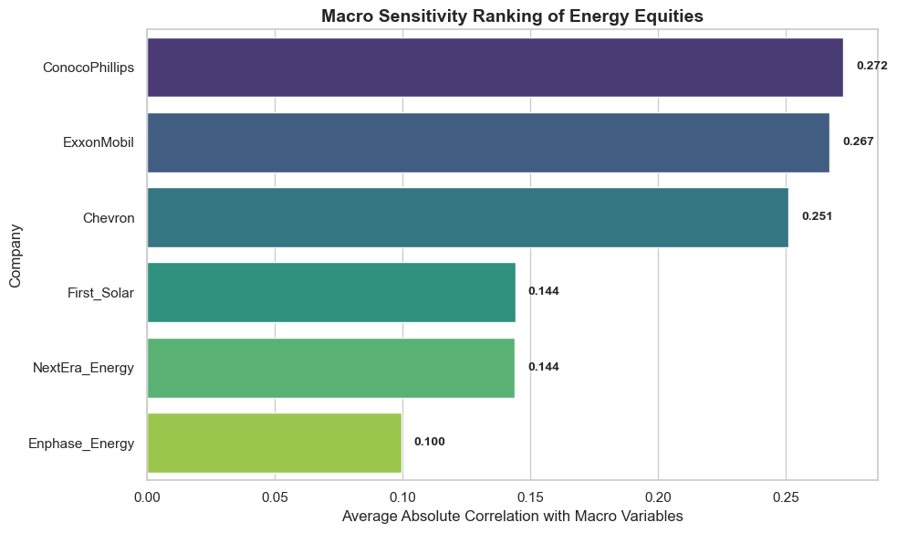

```python
# ============================================================
# Macro Sensitivity Score Ranking
# ============================================================

# Reset the index and rename it clearly as Company
macro_sensitivity_plot = (
    macro_sensitivity_score
    .reset_index()
    .rename(columns={"index": "Company"})
)

plt.figure(figsize=(10, 6))

ax = sns.barplot(
    data=macro_sensitivity_plot,
    x="Macro_Sensitivity_Score",
    y="Company",
    palette="viridis"
)

# Add values at the end of each bar
for i, value in enumerate(macro_sensitivity_plot["Macro_Sensitivity_Score"]):
    ax.text(
        value + 0.005,
        i,
        f"{value:.3f}",
        va="center",
        fontsize=10,
        fontweight="bold"
    )

plt.title(
    "Macro Sensitivity Ranking of Energy Equities",
    fontsize=14,
    fontweight="bold"
)

plt.xlabel("Average Absolute Correlation with Macro Variables")
plt.ylabel("Company")

plt.tight_layout()
plt.show()
```

The Macro Sensitivity Score provides a consolidated measure of how strongly each company's stock returns are associated with broader market and macroeconomic conditions. Rather than examining individual correlations separately, this metric summarizes the average absolute relationship between each stock and the selected external variables, including the S&P 500, crude oil prices, interest rates, inflation, Treasury yields, and GDP.

#### Strategic Market Insight

One of the most important findings from this analysis is the clear distinction between traditional energy companies and renewable energy companies. Oil and gas equities appear significantly more exposed to macroeconomic and market conditions, while renewable energy firms appear comparatively less dependent on external economic variables.

From an investment perspective, stocks with higher macro sensitivity may experience stronger reactions during periods of economic expansion, commodity-price movements, and shifts in investor sentiment. Conversely, companies with lower macro sensitivity may offer greater diversification benefits because their performance is less dependent on broad market conditions.

Overall, the analysis suggests that investors seeking exposure to macroeconomic and commodity-driven opportunities may find greater sensitivity within the traditional energy sector, while investors focused on long-term structural growth themes may find renewable energy companies less tied to short-term economic cycles and more influenced by industry-specific developments.

### 11.5 Sector-Level Macro Sensitivity

```python
# ============================================================
# Sector-Level Macro Sensitivity
# ============================================================

sector_macro_sensitivity = pd.DataFrame({
    "Renewable_Energy": stock_macro_corr.loc[renewable_names].abs().mean(),
    "Oil_Gas": stock_macro_corr.loc[oil_names].abs().mean()
})

sector_macro_sensitivity
```

|  | Renewable_Energy | Oil_Gas |
| --- | --- | --- |
| SP500 | 0.3168 | 0.5225 |
| Crude_Oil | 0.0562 | 0.4824 |
| FEDFUNDS_Change | 0.0989 | 0.1136 |
| CPI_Inflation | 0.0478 | 0.1442 |
| GS10_Change | 0.1705 | 0.1873 |
| GDP_Growth | 0.0850 | 0.1311 |

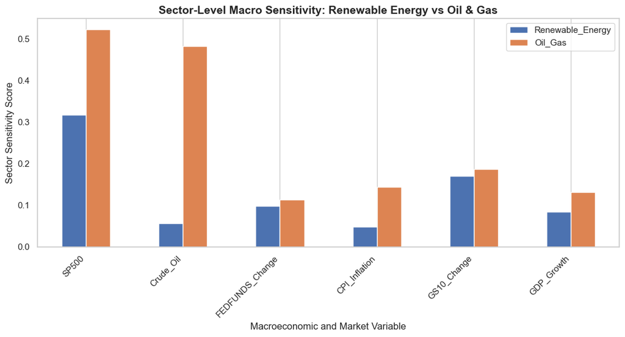

```python
# ============================================================
# Sector-Level Macro Sensitivity Chart
# ============================================================

sector_macro_sensitivity.plot(
    kind="bar",
    figsize=(11, 6)
)

plt.title(
    "Sector-Level Macro Sensitivity: Renewable Energy vs Oil & Gas",
    fontsize=14,
    fontweight="bold"
)

plt.xlabel("Macroeconomic and Market Variable")
plt.ylabel("Sector Sensitivity Score")

plt.xticks(rotation=45, ha="right")
plt.grid(axis="y")

plt.tight_layout()
plt.show()
```

#### Key Takeaway

Oil & Gas = Market + Oil Price Driven

This analysis compares the average macroeconomic sensitivity of renewable energy companies and traditional oil & gas companies across six key market and economic variables. By aggregating company-level sensitivities into sector-level measures, the analysis provides a broader view of the external forces that influence each segment of the energy industry.

Several important differences emerge from the results.

The most significant difference between the two sectors is observed in **crude oil sensitivity**. Oil & gas companies display an average sensitivity of approximately **0.49**, while renewable energy companies exhibit a very weak relationship of only **0.05**. This result is consistent with industry fundamentals, as oil producers generate revenues directly from commodity markets, whereas renewable energy companies are largely insulated from short-term fluctuations in crude oil prices.

#### Strategic Investment Implications

The findings suggest that renewable energy and oil & gas companies should not be viewed as a single homogeneous sector. Instead, they respond to fundamentally different economic drivers.

Traditional oil & gas firms appear to be primarily influenced by:

- Broad equity-market performance
- Crude oil price movements
- Commodity-market conditions

From a portfolio-construction perspective, these differences may create diversification benefits because the two sectors do not react identically to the same economic environment.

Overall, the sector-level analysis reinforces one of the central conclusions of this project: although renewable energy and oil & gas companies operate within the broader energy sector, their return drivers are substantially different, and investors should evaluate them using distinct analytical frameworks rather than treating them as a single asset class.

### 11.6 Classification of Sensitivity Level

```python
# ============================================================
# Classify Macro Sensitivity Level
# ============================================================

def classify_sensitivity(score):
    if score >= 0.30:
        return "High Sensitivity"
    elif score >= 0.15:
        return "Moderate Sensitivity"
    else:
        return "Low Sensitivity"

macro_sensitivity_score["Sensitivity_Level"] = (
    macro_sensitivity_score["Macro_Sensitivity_Score"]
    .apply(classify_sensitivity)
)

macro_sensitivity_score
```

|  | Macro_Sensitivity_Score | Sensitivity_Level |
| --- | --- | --- |
| ConocoPhillips | 0.2725 | Moderate Sensitivity |
| ExxonMobil | 0.2671 | Moderate Sensitivity |
| Chevron | 0.2510 | Moderate Sensitivity |
| First_Solar | 0.1441 | Low Sensitivity |
| NextEra_Energy | 0.1440 | Low Sensitivity |
| Enphase_Energy | 0.0995 | Low Sensitivity |

### 11.7 Sector-Level Macro Sensitivity Analysis

The sector-level macro sensitivity analysis provides a comparative view of how renewable energy companies and traditional oil & gas companies respond to broader market and economic conditions. By examining average sensitivity scores across multiple macroeconomic variables, this analysis identifies the primary external forces that influence each segment of the energy sector.

Several important differences emerge from the results.

A second and more pronounced difference is observed in the relationship with **crude oil prices**. Oil & gas companies demonstrate a very high sensitivity to crude oil, with an average score approaching **0.49**, whereas renewable energy companies exhibit only a weak relationship of approximately **0.05**. This finding is consistent with industry fundamentals, as the revenues and profitability of oil producers are directly influenced by commodity prices, while renewable energy companies operate under fundamentally different economic drivers.

#### Strategic Market Intelligence Insight

One of the most important conclusions from this analysis is that renewable energy and traditional oil & gas companies should not be evaluated using the same investment framework. Although both operate within the broader energy sector, the factors that drive their performance are materially different.

The evidence suggests that:

For investors, analysts, and portfolio managers, these differences are significant. Understanding which macroeconomic variables exert the greatest influence on each sector can improve investment decision-making, risk assessment, and portfolio diversification strategies.

#### Key Takeaway

**Traditional oil & gas equities are primarily commodity-driven, while renewable energy equities are primarily capital-market and growth-driven.**

This distinction represents one of the most important findings of the project and reinforces the need to analyze renewable energy and traditional energy companies as separate investment categories rather than treating them as a single homogeneous sector.

# **12. Market Intelligence Signal Framework**

The preceding analyses identified several factors that appear to influence energy-equity performance, including market sentiment, crude oil prices, interest-rate conditions, volatility, and broader economic trends.

This section transforms those findings into a practical market intelligence framework. Rather than attempting to predict future stock prices with certainty, the framework combines selected market and macroeconomic indicators into a structured monitoring system designed to identify periods that may warrant further investment research.

The objective is not to create a trading strategy or provide investment recommendations. Instead, the framework serves as a decision-support tool that helps analysts, investors, and researchers evaluate whether current market conditions resemble historical environments that were more supportive of energy equity performance.

The framework uses three core signals:

1. Market Pullback Signal
2. Oil Momentum Signal
3. Rate Relief Signal

These signals are then combined into a Composite Opportunity Score.

```python
# ============================================================
# Initialize Signal Framework
# ============================================================

signals = pd.DataFrame(index=stock_returns.index)
```

### 12.1 Signal 1: Market Pullback Signal

The Market Pullback Signal is designed to identify periods of significant price weakness within the energy equity universe.

A pullback may create a potential research opportunity when market participants become overly pessimistic or when prices decline sharply relative to recent expectations. However, a large decline does not guarantee a future recovery. For this reason, the signal is used only as a screening tool, not as a direct buy recommendation.

For this project, the portfolio-level Pullback Signal is activated when at least one company in the selected energy equity universe experiences a monthly decline of 10% or more.

#### Signal Definition

Market Pullback Signal = 1 when:

Monthly stock return ≤ -10%

Otherwise:

Market Pullback Signal = 0

```python
# ============================================================
# Signal 1: Market Pullback Signal
# ============================================================

pullback_threshold = -0.10

for stock in stock_names:
    signals[f"{stock}_Pullback_Signal"] = (
        stock_returns[stock] <= pullback_threshold
    ).astype(int)

signals["Pullback_Signal"] = signals[
    [f"{stock}_Pullback_Signal" for stock in stock_names]
].max(axis=1)

signals[
    [f"{stock}_Pullback_Signal" for stock in stock_names] + ["Pullback_Signal"]
].head()
```

| Date | NextEra_Energy_Pullback_Signal | First_Solar_Pullback_Signal | Enphase_Energy_Pullback_Signal | ExxonMobil_Pullback_Signal | Chevron_Pullback_Signal | ConocoPhillips_Pullback_Signal | Pullback_Signal |
| --- | --- | --- | --- | --- | --- | --- | --- |
| 2012-05-31 | 0 | 1 | 0 | 0 | 0 | 0 | 1 |
| 2012-06-30 | 0 | 0 | 0 | 0 | 0 | 0 | 0 |
| 2012-07-31 | 0 | 0 | 0 | 0 | 0 | 0 | 0 |
| 2012-08-31 | 0 | 0 | 1 | 0 | 0 | 0 | 1 |
| 2012-09-30 | 0 | 0 | 1 | 0 | 0 | 0 | 1 |

The Pullback Signal identifies months when at least one company in the energy equity universe experienced a decline of 10% or more. This captures periods of sector stress or company-specific weakness that may deserve closer analysis.

### 12.2 Signal 2: Oil Momentum Signal

The Oil Momentum Signal captures periods when crude oil prices are rising.

The oil regime and macro sensitivity analyses showed that traditional oil and gas companies have strong exposure to crude oil price movements. Rising oil prices may improve revenue expectations, profitability forecasts, and investor sentiment toward oil-producing companies.

#### Signal Definition

Oil Momentum Signal = 1 when:

Monthly crude oil return > 0

Otherwise:

Oil Momentum Signal = 0

```python
# ============================================================
# Signal 2: Oil Momentum Signal
# ============================================================

signals["Oil_Momentum_Signal"] = (
    monthly_returns["Crude_Oil"]
    .reindex(signals.index)
    > 0
).astype(int)

signals[["Oil_Momentum_Signal"]].head()
```

| Date | Oil_Momentum_Signal |
| --- | --- |
| 2012-05-31 | 0 |
| 2012-06-30 | 0 |
| 2012-07-31 | 1 |
| 2012-08-31 | 1 |
| 2012-09-30 | 0 |

The Oil Momentum Signal identifies months when crude oil prices increased. This signal is particularly relevant for traditional oil and gas equities because their earnings expectations are often closely linked to commodity-market conditions.

### 12.3 Signal 3: Rate Relief Signal

The Rate Relief Signal captures periods when monetary policy conditions become more supportive or less restrictive.

Stable or declining interest rates may reduce financing pressure, lower discount-rate expectations, and improve investor sentiment toward long-duration growth assets. This can be especially relevant for renewable energy companies, which often depend on capital-intensive projects and long-term financing.

#### Signal Definition

Rate Relief Signal = 1 when:

Change in Federal Funds Rate ≤ 0

Otherwise:

Rate Relief Signal = 0

```python
# ============================================================
# Signal 3: Rate Relief Signal
# ============================================================

signals["Rate_Relief_Signal"] = (
    fred_monthly["FEDFUNDS"]
    .reindex(signals.index)
    .diff()
    <= 0
).astype(int)

signals[["Rate_Relief_Signal"]].head()
```

| Date | Rate_Relief_Signal |
| --- | --- |
| 2012-05-31 | 0 |
| 2012-06-30 | 1 |
| 2012-07-31 | 1 |
| 2012-08-31 | 1 |
| 2012-09-30 | 0 |

The Rate Relief Signal identifies months when the Federal Funds Rate declined or remained unchanged. This signal is designed to capture periods when monetary policy conditions may be less restrictive for energy-sector investment.

### 12.4 Composite Opportunity Score

Individual signals provide useful information, but no single indicator fully captures market conditions. Professional investment research often combines multiple indicators to create a broader decision-support framework.

To create a more comprehensive market-monitoring tool, the three signals are combined into a Composite Opportunity Score.

#### Scoring Methodology

+1 Market Pullback Signal  
+1 Oil Momentum Signal  
+1 Rate Relief Signal

#### Score Range

0 = Weak Opportunity Environment  
1 = Mild Opportunity Environment  
2 = Favorable Opportunity Environment  
3 = High Opportunity Environment

Higher scores indicate that multiple favorable conditions are occurring simultaneously. The score is not intended to predict future returns with certainty. Instead, it highlights periods where historical conditions may have been more supportive of energy equities.

```python
# ============================================================
# Composite Opportunity Score
# ============================================================

signals["Opportunity_Score"] = (
    signals["Pullback_Signal"] +
    signals["Oil_Momentum_Signal"] +
    signals["Rate_Relief_Signal"]
)

signals[
    [
        "Rate_Relief_Signal",
        "Oil_Momentum_Signal",
        "Pullback_Signal",
        "Opportunity_Score"
    ]
].head()
```

| Date | Rate_Relief_Signal | Oil_Momentum_Signal | Pullback_Signal | Opportunity_Score |
| --- | --- | --- | --- | --- |
| 2012-05-31 | 0 | 0 | 1 | 1 |
| 2012-06-30 | 1 | 0 | 0 | 1 |
| 2012-07-31 | 1 | 1 | 0 | 2 |
| 2012-08-31 | 1 | 1 | 1 | 3 |
| 2012-09-30 | 0 | 0 | 1 | 1 |

The Composite Opportunity Score combines pullback conditions, oil momentum, and interest-rate conditions into one interpretable score. This creates a simple but structured market-monitoring framework that can be evaluated against future returns.

## **13. Signal Performance Evaluation**

Developing signals is only valuable if those signals provide useful information about future market behavior. Therefore, this section evaluates whether the Market Intelligence Signal Framework was historically associated with stronger subsequent returns.

The objective is not to determine whether the signals perfectly predict future performance. Instead, the goal is to assess whether periods with stronger signal conditions were generally followed by more favorable investment outcomes.

To evaluate the framework, the Composite Opportunity Score is compared against next-month stock returns. Forward returns represent the performance observed during the month immediately following each signal observation.

### 13.1 Create Forward Returns

Forward returns are created by shifting monthly stock returns one period into the future. This allows the analysis to compare current signal conditions with the return observed in the following month.

```python
# ============================================================
# Create Forward Returns
# ============================================================

forward_returns = stock_returns.shift(-1)

forward_returns.head()
```

| Ticker Date | NextEra_Energy | First_Solar | Enphase_Energy | ExxonMobil | Chevron | ConocoPhillips |
| --- | --- | --- | --- | --- | --- | --- |
| 2012-05-31 | 0.0531 | 0.1990 | -0.0986 | 0.0883 | 0.0731 | 0.0713 |
| 2012-06-30 | 0.0304 | 0.0319 | -0.0659 | 0.0150 | 0.0387 | -0.0143 |
| 2012-07-31 | -0.0422 | 0.2864 | -0.1463 | 0.0117 | 0.0317 | 0.0432 |
| 2012-08-31 | 0.0449 | 0.1081 | -0.1653 | 0.0475 | 0.0392 | 0.0069 |
| 2012-09-30 | -0.0038 | 0.0971 | -0.1135 | -0.0031 | -0.0542 | 0.0235 |

### 13.2 Combine Opportunity Scores with Forward Returns

The Opportunity Score is combined with forward returns to create the signal evaluation dataset. Each row represents one month, the signal score observed during that month, and the stock returns that occurred in the following month.

```python
# ============================================================
# Combine Opportunity Score with Forward Returns
# ============================================================

signal_evaluation = pd.concat(
    [
        signals["Opportunity_Score"],
        forward_returns
    ],
    axis=1
).dropna()

signal_evaluation.head()
```

| Date | Opportunity_Score | NextEra_Energy | First_Solar | Enphase_Energy | ExxonMobil | Chevron | ConocoPhillips |
| --- | --- | --- | --- | --- | --- | --- | --- |
| 2012-05-31 | 1 | 0.0531 | 0.1990 | -0.0986 | 0.0883 | 0.0731 | 0.0713 |
| 2012-06-30 | 1 | 0.0304 | 0.0319 | -0.0659 | 0.0150 | 0.0387 | -0.0143 |
| 2012-07-31 | 2 | -0.0422 | 0.2864 | -0.1463 | 0.0117 | 0.0317 | 0.0432 |
| 2012-08-31 | 3 | 0.0449 | 0.1081 | -0.1653 | 0.0475 | 0.0392 | 0.0069 |
| 2012-09-30 | 1 | -0.0038 | 0.0971 | -0.1135 | -0.0031 | -0.0542 | 0.0235 |

### 13.3 Average Future Returns by Opportunity Score

This analysis calculates the average next-month return for each stock under each Opportunity Score category. The purpose is to determine whether higher scores were historically associated with stronger future returns.

```python
# ============================================================
# Average Future Returns by Opportunity Score
# ============================================================

score_performance = (
    signal_evaluation
    .groupby("Opportunity_Score")[stock_names]
    .mean()
)

score_performance
```

| Opportunity_Score | NextEra_Energy | First_Solar | Enphase_Energy | ExxonMobil | Chevron | ConocoPhillips |
| --- | --- | --- | --- | --- | --- | --- |
| 0 | -0.0022 | 0.0136 | 0.0509 | 0.0093 | 0.0127 | 0.0280 |
| 1 | 0.0143 | 0.0157 | -0.0009 | -0.0051 | -0.0146 | -0.0205 |
| 2 | 0.0209 | 0.0525 | 0.0708 | 0.0158 | 0.0214 | 0.0261 |
| 3 | 0.0038 | 0.0144 | 0.0182 | 0.0238 | 0.0332 | 0.0394 |

### 13.4 Equal-Weighted Energy Portfolio Performance

To evaluate the signal framework at the portfolio level, an equal-weighted energy portfolio is created by averaging the next-month returns of all six selected energy equities. This portfolio-level view provides a cleaner assessment of whether the Opportunity Score was associated with stronger overall energy-sector performance.

```python
# ============================================================
# Equal-Weighted Energy Portfolio
# ============================================================

signal_evaluation["Energy_Portfolio"] = (
    signal_evaluation[stock_names]
    .mean(axis=1)
)

portfolio_performance = (
    signal_evaluation
    .groupby("Opportunity_Score")["Energy_Portfolio"]
    .mean()
)

portfolio_performance
```

```
Opportunity_Score
0    0.0187
1   -0.0019
2    0.0346
3    0.0221
Name: Energy_Portfolio, dtype: float64
```

### 13.5 Opportunity Score Performance Chart

The chart below visualizes the average next-month return of the equal-weighted energy portfolio under each Opportunity Score category.

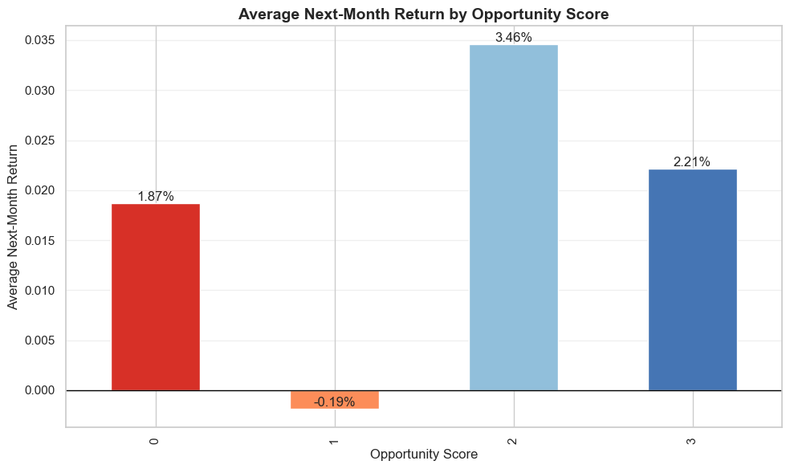

```python
# ============================================================
# Opportunity Score Performance
# ============================================================

plt.figure(figsize=(10,6))

portfolio_performance.plot(
    kind="bar",
    color=["#D73027", "#FC8D59", "#91BFDB", "#4575B4"]
)

plt.title(
    "Average Next-Month Return by Opportunity Score",
    fontsize=14,
    fontweight="bold"
)

plt.xlabel("Opportunity Score")
plt.ylabel("Average Next-Month Return")

plt.axhline(
    0,
    color="black",
    linewidth=1
)

plt.grid(axis="y", alpha=0.3)

plt.tight_layout()

for i, value in enumerate(portfolio_performance):
    plt.text(
        i,
        value,
        f"{value:.2%}",
        ha="center",
        va="bottom"
    )

plt.show()
```

### 13.6 Signal Observation Counts

Observation counts are important because signal categories with very few observations may produce less reliable results. This table shows how often each Opportunity Score occurred during the study period.

```python
# ============================================================
# Opportunity Score Observation Counts
# ============================================================

signal_counts = (
    signal_evaluation["Opportunity_Score"]
    .value_counts()
    .sort_index()
)

signal_counts
```

```
Opportunity_Score
0    18
1    60
2    64
3    21
Name: count, dtype: int64
```

### 13.7 Signal Evaluation Summary Table

Average returns alone can be affected by outliers. To provide a more complete evaluation, the table below includes observation count, average return, median return, and win rate for each Opportunity Score category. The win rate measures the percentage of months in which the equal-weighted energy portfolio generated a positive next-month return.

```python
# ============================================================
# Signal Evaluation Summary Table
# ============================================================

score_summary = (
    signal_evaluation
    .groupby("Opportunity_Score")["Energy_Portfolio"]
    .agg(
        Observation_Count="count",
        Average_Next_Month_Return="mean",
        Median_Next_Month_Return="median",
        Win_Rate=lambda x: (x > 0).mean()
    )
)

score_summary
```

| Opportunity_Score | Observation_Count | Average_Next_Month_Return | Median_Next_Month_Return | Win_Rate |
| --- | --- | --- | --- | --- |
| 0 | 18 | 0.0187 | 0.0229 | 0.6111 |
| 1 | 60 | -0.0019 | -0.0031 | 0.4833 |
| 2 | 64 | 0.0346 | 0.0324 | 0.6719 |
| 3 | 21 | 0.0221 | 0.0198 | 0.7143 |

The Market Intelligence Signal Framework was evaluated by comparing Opportunity Scores with subsequent one-month returns for the equal-weighted energy portfolio.

The results show that the framework captures meaningful differences in market environments. The strongest performance occurred when the Opportunity Score reached **2**, generating an average next-month portfolio return of approximately **3.46%**. This result is especially important because Score 2 occurred **64 times**, making it the most frequent and most reliable signal category in the analysis.

Periods with an Opportunity Score of **3** also produced strong results, generating an average next-month return of approximately **2.21%** across **21 observations**. Although Score 3 occurred less frequently than Score 2, its positive performance supports the idea that multiple favorable market conditions can be associated with stronger future returns.

In contrast, periods with an Opportunity Score of **1** generated a slightly negative average next-month return of approximately **-0.19%** across **60 observations**. This suggests that isolated signals may not provide enough information when evaluated on their own.

Interestingly, periods with an Opportunity Score of **0** still produced a positive average next-month return of approximately **1.87%** across **18 observations**. This highlights an important reality of financial markets: positive returns can still occur even when the selected signal conditions are absent. Stock performance may also be influenced by company-specific news, earnings results, policy changes, geopolitical events, and investor sentiment.

#### Reliability of Results

The observation counts provide useful context for evaluating the reliability of the results:

| Opportunity Score | Number of Observations |
| --- | --- |
| 0 | 18 |
| 1 | 60 |
| 2 | 64 |
| 3 | 21 |

The strongest-performing category, Score 2, is supported by the largest number of observations. This strengthens the credibility of the result and reduces the likelihood that the finding is driven by only a few unusual months.

#### Strategic Investment Insight

The results suggest that the signal framework is most informative when multiple favorable conditions occur simultaneously. Opportunity Scores of **2 and 3** were associated with the strongest forward returns, while a single isolated signal was not enough to produce strong performance.

This supports the use of a multi-factor market intelligence framework rather than relying on one indicator alone. The framework does not predict future returns with certainty, but it provides a structured and evidence-based method for identifying historical environments that were more supportive of energy-sector performance.

#### Key Takeaway

Energy equities performed best when multiple favorable conditions occurred at the same time. The results support the idea that combining market pullbacks, oil momentum, and interest-rate conditions can provide useful context for energy-sector investment research and market monitoring.

## **14. Key Findings**

The objective of this project was to investigate whether market conditions, macroeconomic variables, and energy-market indicators could provide useful signals for identifying potentially attractive investment opportunities within renewable energy and traditional oil & gas equities.

The analysis generated several important findings regarding performance, risk, macroeconomic sensitivity, and market conditions.

#### Finding 1: Renewable Energy Stocks Delivered Higher Long-Term Returns but Experienced Significantly Greater Risk

The performance analysis revealed that renewable energy companies generated substantially stronger long-term returns than traditional oil & gas firms during the study period. In particular, Enphase Energy and First Solar produced the highest average returns among the companies analyzed.

However, these higher returns came at the cost of substantially greater volatility and downside risk. Renewable energy equities experienced larger price fluctuations, deeper drawdowns, and greater sensitivity to changing economic conditions.

This finding highlights the classic investment trade-off between risk and return. Investors seeking higher growth opportunities may benefit from renewable energy exposure, but must also be willing to tolerate greater uncertainty and larger short-term losses.

#### Finding 2: Traditional Oil & Gas Companies Demonstrated Greater Stability

While oil & gas companies generally produced lower returns than renewable energy firms, they exhibited significantly lower volatility and more stable performance across market cycles.

Companies such as ExxonMobil, Chevron, and ConocoPhillips experienced smaller drawdowns and more consistent return patterns throughout the study period.

These results suggest that traditional energy companies may serve a stabilizing role within diversified portfolios, particularly during periods of economic uncertainty or market stress.

#### Finding 3: Renewable Energy and Oil & Gas Equities Respond to Different Economic Drivers

One of the strongest findings of the project is that renewable energy and traditional energy companies should not be treated as a single homogeneous sector.

The macroeconomic sensitivity analysis demonstrated that oil & gas companies are primarily influenced by:

- Crude oil prices
- Broad equity-market performance
- Commodity-market conditions

In contrast, renewable energy companies exhibited greater sensitivity to:

- Interest-rate conditions
- Treasury yields
- Inflation expectations
- Economic growth trends

These differences suggest that investors should evaluate renewable energy and traditional energy companies using separate analytical frameworks rather than relying on a single sector-wide approach.

#### Finding 4: Market Regimes Have a Meaningful Impact on Energy Equity Performance

The Market Regime Analysis demonstrated that energy-stock performance varies substantially across different economic and market environments.

Most companies produced significantly stronger returns during positive market regimes than during negative market regimes. Renewable energy companies, in particular, showed greater sensitivity to broader market conditions and investor sentiment.

This finding reinforces the importance of monitoring overall market trends when evaluating opportunities within the energy sector.

#### Finding 5: Oil Price Regimes Affect Traditional Energy Companies More Than Renewable Energy Companies

The Oil Regime Analysis revealed that traditional oil & gas firms benefited considerably more from high-oil-price environments than renewable energy companies.

ExxonMobil, Chevron, and ConocoPhillips all generated stronger average returns during periods characterized by higher crude oil prices. Renewable energy companies displayed much weaker relationships with oil-price movements, suggesting that their performance is driven primarily by factors other than commodity prices.

This finding aligns closely with the sector-level macro sensitivity analysis and confirms the importance of crude oil prices as a key driver of traditional energy-sector performance.

#### Finding 6: Multiple Signals Are More Informative Than Individual Signals

The Signal Performance Evaluation demonstrated that combining multiple indicators into a single Opportunity Score provided more useful information than relying on individual signals in isolation.

This result supports the use of multi-factor frameworks for investment research and market monitoring.

#### Finding 7: The Market Intelligence Signal Framework Shows Practical Value

The final analysis suggests that the Market Intelligence Signal Framework successfully differentiated between weaker and stronger historical investment environments.

While the framework does not perfectly predict future returns, it provides a structured method for monitoring:

- Interest-rate conditions
- Commodity-market trends
- Market pullbacks
- Broader investment environments

The framework therefore has potential value as a decision-support tool for investors, analysts, and researchers seeking to better understand opportunities within the energy sector.

#### Conclusion

The findings indicate that energy equities are influenced by a complex combination of market conditions, commodity prices, macroeconomic factors, and investor sentiment. Renewable energy and traditional oil & gas companies exhibit fundamentally different performance drivers and risk characteristics, making sector-specific analysis essential.

Most importantly, the results demonstrate that combining multiple indicators into a unified market intelligence framework provides more informative insights than evaluating individual variables independently. This supports the project's central thesis that macroeconomic and market-based signals can contribute meaningfully to identifying favorable investment environments within the energy sector.

## **15. Strategic Investment Implications**

The findings of this analysis have several implications for investors, portfolio managers, energy-sector analysts, and market researchers. While historical relationships should not be interpreted as guarantees of future performance, the results provide valuable insight into how different segments of the energy sector respond to changing market and economic conditions.

The analysis suggests that investment opportunities within the energy sector are not driven by a single factor. Instead, successful evaluation requires consideration of market conditions, commodity-price trends, monetary policy, and company-specific risk characteristics.

#### Implication 1: Renewable Energy and Oil & Gas Should Be Evaluated Separately

One of the strongest conclusions from this project is that renewable energy companies and traditional oil & gas companies respond to fundamentally different economic drivers.

Traditional energy firms were shown to have stronger relationships with crude oil prices and broader market conditions, while renewable energy companies exhibited greater sensitivity to interest rates, inflation expectations, and economic growth trends.

As a result, investors should avoid treating the energy sector as a single homogeneous asset class. Instead, sector allocation decisions should consider the distinct risk-return characteristics and macroeconomic exposures of each segment.

#### Implication 2: Market Conditions Matter More Than Individual Indicators

The Signal Performance Evaluation demonstrated that no single indicator consistently explained future performance. Instead, stronger investment outcomes were generally observed when multiple favorable conditions occurred simultaneously.

This finding supports the use of multi-factor decision frameworks rather than relying on isolated indicators such as oil prices, interest rates, or market momentum alone.

For investors, this suggests that evaluating opportunities through a broader market-intelligence framework may provide more useful insights than focusing exclusively on a single economic variable.

#### Implication 3: Risk Management Is as Important as Return Generation

The analysis revealed significant differences in volatility and downside risk across companies.

Renewable energy firms generated higher average returns but also experienced substantially larger drawdowns and greater volatility. Traditional oil & gas companies exhibited more stable return patterns but generally lower long-term growth.

These findings highlight the importance of balancing return expectations with risk considerations when constructing energy-sector portfolios.

Investors pursuing higher-growth opportunities may benefit from renewable energy exposure, while investors seeking greater stability may find traditional energy firms more attractive.

#### Implication 4: Macroeconomic Monitoring Can Improve Investment Research

The macroeconomic sensitivity analysis demonstrated that several external variables exert meaningful influence on energy-sector performance.

Among the most important factors identified were:

- Broad equity-market performance (S&P 500)
- Crude oil prices
- Interest-rate conditions
- Treasury yields
- Economic growth expectations

Monitoring these indicators may help investors better understand changes in market conditions and identify periods that warrant deeper fundamental analysis.

The findings suggest that energy-sector performance should be evaluated within the broader context of economic and financial-market developments rather than through company-level analysis alone.

#### Implication 5: Market Pullbacks May Create Research Opportunities

The drawdown and signal analyses indicate that significant market declines are often followed by periods of recovery.

Although pullbacks do not guarantee future gains, periods of substantial price weakness may provide opportunities for further investigation, particularly when supported by favorable macroeconomic or commodity-market conditions.

From a research perspective, market pullbacks should be viewed as potential opportunity-identification events rather than automatic buy signals.

#### Implication 6: A Structured Market Intelligence Framework Can Support Decision-Making

The Opportunity Score framework developed in this project demonstrates how multiple indicators can be combined into a practical monitoring system.

Rather than attempting to forecast exact future prices, the framework provides a structured method for evaluating:

- Market sentiment
- Commodity-market conditions
- Monetary policy environments
- Relative opportunity levels

This approach more closely resembles how professional investment organizations evaluate uncertainty and assess changing market conditions.

#### Strategic Takeaway

The energy sector is influenced by a complex interaction of market forces, commodity prices, and macroeconomic conditions. The findings of this project suggest that investors may benefit from adopting a multi-factor approach that considers both sector-specific drivers and broader economic trends.

Most importantly, the results demonstrate that combining market, commodity, and macroeconomic signals provides more informative insights than evaluating individual indicators independently. This reinforces the value of a structured market-intelligence framework as a tool for investment research, risk assessment, and strategic decision-making within the energy sector.

## **16. Limitations and Risk Considerations**

While the findings of this project provide valuable insights into the relationship between market conditions, macroeconomic factors, and energy-equity performance, several limitations should be considered when interpreting the results.

Understanding these limitations is essential because financial markets are complex systems influenced by numerous interconnected factors that cannot be fully captured within a single analytical framework.

#### Limitation 1: Historical Relationships May Not Persist

The analysis is based entirely on historical data between 2012 and 2025. Financial markets are dynamic, and relationships observed during one period may weaken, strengthen, or disappear entirely in the future.

Changes in economic conditions, technological innovation, government policy, geopolitical developments, or investor behavior may alter the factors that drive energy-sector performance.

As a result, historical patterns should not be interpreted as guarantees of future outcomes.

#### Limitation 2: Correlation Does Not Imply Causation

Many of the findings presented in this project are based on statistical relationships between variables.

Although correlations can reveal meaningful associations, they do not establish direct causal relationships. For example, a strong relationship between energy stocks and crude oil prices does not necessarily mean that oil prices are the sole cause of stock-price movements.

Additional factors may influence both variables simultaneously.

Therefore, the results should be interpreted as evidence of association rather than proof of causation.

#### Limitation 3: Limited Company Sample

The analysis focuses on a selected group of representative renewable energy and oil & gas companies.

While these firms provide useful insight into their respective sectors, they do not capture the full diversity of the global energy industry.

Different companies may exhibit different sensitivities depending on:

- Business model
- Geographic exposure
- Regulatory environment
- Capital structure
- Growth strategy

Future research could expand the sample to include a broader range of energy companies and exchange-traded funds (ETFs).

#### Limitation 4: Simplified Signal Framework

The Opportunity Score framework was intentionally designed to be transparent and interpretable.

Although simplicity improves understanding and usability, it may not capture the full complexity of financial markets.

Professional investment organizations often incorporate:

- Valuation metrics
- Earnings expectations
- Analyst revisions
- Options-market data
- Economic forecasts
- Alternative datasets

Consequently, the framework should be viewed as an exploratory decision-support tool rather than a complete investment model.

#### Limitation 5: Macroeconomic Variables May Operate With Time Lags

The analysis primarily evaluates contemporaneous relationships between macroeconomic variables and stock returns.

In practice, economic changes often affect financial markets with delays that can range from weeks to several quarters.

For example:

- Interest-rate changes may influence corporate investment decisions over time.
- Inflation expectations may affect valuations gradually.
- Economic growth trends may take months to influence company earnings.

Future research could investigate lagged relationships to better capture these effects.

#### Limitation 6: Company-Specific Events Are Not Captured

Stock prices are influenced not only by market and macroeconomic factors but also by company-specific developments.

Examples include:

- Earnings announcements
- Mergers and acquisitions
- Management changes
- Product launches
- Regulatory decisions
- Legal disputes

Because these events were not explicitly incorporated into the analysis, some observed price movements may reflect factors unrelated to the variables examined in this project.

#### Limitation 7: Transaction Costs and Portfolio Constraints

The signal evaluation assumes that investors can respond immediately to changing market conditions without incurring costs.

In reality, investment decisions involve:

- Transaction costs
- Bid-ask spreads
- Taxes
- Liquidity constraints
- Portfolio allocation restrictions

These factors may reduce the practical effectiveness of any investment strategy derived from historical signals.

#### Risk Considerations

Investors should recognize that energy-sector investments involve significant uncertainty and risk.

Key risks include:

- Market Risk. Broad market downturns can negatively affect both renewable energy and traditional energy companies regardless of underlying fundamentals.
- Commodity Price Risk. Traditional energy firms remain highly sensitive to fluctuations in crude oil and natural gas prices.
- Interest Rate Risk. Renewable energy companies may be particularly vulnerable to rising interest rates due to their reliance on long-term capital investment and financing.
- Regulatory and Policy Risk. Changes in environmental regulations, energy policy, subsidies, carbon pricing mechanisms, or taxation can materially impact company performance.
- Geopolitical Risk. Energy markets are influenced by geopolitical events, international conflicts, trade restrictions, and supply-chain disruptions.

#### Final Perspective

The limitations outlined above do not invalidate the findings of this project. Rather, they provide important context for interpreting the results responsibly.

The objective of this analysis is not to predict future stock prices with certainty, but to develop a structured market-intelligence framework that improves understanding of how energy equities have historically responded to changing market and economic conditions.

Recognizing uncertainty is a critical component of sound investment research. Consequently, the findings should be viewed as a foundation for informed decision-making and further investigation rather than as definitive investment recommendations.

## **17. Future Enhancements**

While the Market Intelligence Signal Framework provides valuable insights into the relationship between macroeconomic conditions, energy-market dynamics, and equity performance, several opportunities exist to further expand the analytical capabilities of the framework.

The current project should be viewed as a foundational market-intelligence prototype that can be enhanced through additional data sources, advanced modeling techniques, and automated decision-support systems.

#### Enhancement 1: Expand the Energy Equity Universe

The analysis focused on a selected group of renewable energy and traditional oil & gas companies. Future versions could incorporate a broader range of companies across multiple energy subsectors.

Potential additions include:

- Solar energy companies
- Wind energy companies
- Utility-scale renewable developers
- Energy storage companies
- Midstream energy firms
- Integrated oil majors
- International energy companies

Expanding the company universe would improve the representativeness of the analysis and provide a more comprehensive view of global energy markets.

#### Enhancement 2: Incorporate Energy Exchange-Traded Funds (ETFs)

Institutional investors frequently evaluate sectors through ETFs rather than individual companies.

Future versions of the framework could incorporate:

- XLE (Energy Select Sector SPDR Fund)
- ICLN (iShares Global Clean Energy ETF)
- TAN (Invesco Solar ETF)
- PBW (Invesco WilderHill Clean Energy ETF)

Analyzing sector-level investment vehicles would provide additional insight into how broader energy themes respond to changing market conditions.

#### Enhancement 3: Introduce Valuation Metrics

The current framework focuses primarily on market behavior and macroeconomic indicators.

Future research could incorporate valuation metrics such as:

- Price-to-Earnings Ratio (P/E)
- Enterprise Value to EBITDA (EV/EBITDA)
- Price-to-Book Ratio (P/B)
- Free Cash Flow Yield
- Dividend Yield

Combining valuation measures with macroeconomic signals could improve the identification of attractive investment opportunities.

#### Enhancement 4: Integrate Energy Market Fundamentals

Professional energy research firms often incorporate industry-specific variables beyond stock prices and macroeconomic indicators.

Examples include:

- Global oil demand forecasts
- OPEC production levels
- U.S. crude oil inventories
- Natural gas prices
- Renewable energy installation growth
- Electricity demand trends
- Carbon credit prices

Integrating these variables would create a more comprehensive energy-market intelligence framework.

#### Enhancement 5: News and Sentiment Analysis

Financial markets are influenced not only by economic fundamentals but also by investor sentiment and information flow.

Future versions could incorporate:

- Financial news sentiment
- Energy-sector news coverage
- Earnings-call transcripts
- Analyst recommendations
- Social media sentiment indicators

Natural Language Processing (NLP) techniques could be used to quantify sentiment and evaluate its relationship with future stock performance.

#### Enhancement 6: Machine Learning-Based Signal Models

The current framework utilizes transparent rule-based signals that prioritize interpretability.

Future research could explore machine learning models such as:

- Random Forests
- XGBoost
- Gradient Boosting Machines
- Logistic Regression
- Neural Networks

These models could be trained to predict the probability of positive future returns using a broader set of market, macroeconomic, and company-specific variables.

However, model interpretability should remain a priority because investment decisions require transparency and explainability.

#### Enhancement 7: Automated Market Intelligence Dashboard

One of the most practical extensions of this project would be the development of an automated dashboard.

Such a dashboard could:

- Update market data automatically
- Monitor macroeconomic indicators in real time
- Recalculate Opportunity Scores
- Generate visual reports
- Track changing market conditions
- Alert users when favorable signal environments emerge

This would transform the project from a research notebook into a practical decision-support platform.

#### Enhancement 8: Forecasting and Scenario Analysis

Future versions could move beyond historical analysis and incorporate forecasting techniques.

Potential applications include:

- Interest-rate scenarios
- Oil-price forecasts
- Economic growth projections
- Inflation scenarios
- Stress-testing exercises

Scenario analysis would allow investors and analysts to evaluate how different economic environments might affect renewable energy and traditional energy companies.

#### Long-Term Vision

The long-term vision for this framework is to evolve from a historical analysis tool into a comprehensive Energy Market Intelligence Platform capable of integrating market data, macroeconomic indicators, industry fundamentals, and predictive analytics.

Such a platform could support investment research, portfolio construction, risk management, and strategic decision-making across both renewable energy and traditional energy sectors.

By combining data science, financial analysis, and energy-market research, future versions of this framework could provide a scalable and practical solution for monitoring opportunities within an increasingly complex global energy landscape.

## **18. Final Conclusion**

The objective of this project was to investigate whether macroeconomic indicators, energy-market dynamics, and market-based signals could provide meaningful insight into identifying favorable investment environments within the energy sector.

To address this objective, the project developed a comprehensive Energy Market Intelligence Framework that integrated equity market data, commodity-market indicators, and macroeconomic variables into a structured analytical workflow. The analysis combined historical stock performance, volatility assessment, drawdown analysis, market regime analysis, macroeconomic sensitivity analysis, and signal evaluation to better understand the factors influencing renewable energy and traditional oil & gas equities.

Several important conclusions emerged from the research.

First, renewable energy companies demonstrated stronger long-term growth potential but also experienced substantially higher volatility and downside risk. Traditional oil & gas companies generally produced more stable performance and exhibited stronger relationships with commodity-market conditions, particularly crude oil prices. These findings reinforce the importance of understanding the distinct characteristics of different segments within the energy sector rather than treating energy equities as a single homogeneous asset class.

Second, the analysis revealed that renewable energy and traditional energy companies respond to fundamentally different economic drivers. Oil & gas firms were more heavily influenced by crude oil prices and broad market conditions, while renewable energy companies exhibited greater sensitivity to interest rates, Treasury yields, inflation expectations, and economic growth trends. This distinction has important implications for portfolio construction, risk management, and sector allocation decisions.

Third, the Market Intelligence Signal Framework demonstrated that combining multiple indicators provided more useful information than relying on individual variables in isolation. Periods characterized by multiple favorable conditions generally produced stronger subsequent returns than environments supported by only a single signal. Although the framework was not designed to predict future stock prices with certainty, it successfully differentiated between weaker and stronger historical investment environments.

Beyond the individual findings, the project highlights the broader value of integrating data science with financial and energy-market analysis. Modern investment research increasingly relies on the ability to collect, process, visualize, and interpret large amounts of data across multiple domains. By combining financial market data, macroeconomic indicators, and structured analytical techniques, this project demonstrates how data-driven approaches can support more informed decision-making within complex sectors such as energy.

The results should not be interpreted as investment recommendations or guarantees of future performance. Financial markets remain inherently uncertain, and future outcomes will continue to be influenced by factors beyond those captured in this analysis. Nevertheless, the framework developed in this project provides a practical foundation for monitoring market conditions, evaluating investment environments, and supporting future research.

Ultimately, this project demonstrates that energy-sector performance is shaped by a dynamic interaction of market sentiment, commodity prices, monetary policy, economic conditions, and company-specific factors. Understanding these relationships through a structured market-intelligence framework can help investors, analysts, and researchers make more informed decisions in an increasingly complex and rapidly evolving energy landscape.

## Final Takeaway

**The strongest investment insights emerged not from any single indicator, but from the combination of market, commodity, and macroeconomic signals. The findings suggest that a multi-factor market intelligence approach provides a more comprehensive understanding of energy-sector opportunities than evaluating individual variables independently.**